# FLicc user guide

Multi-gear length-interval catch-curve analysis in FLR

Henning Winker (FAO-NFI)

17 October 2026

This guide extends the introductory vignette (`vignettes/FLicc_intro_vignette.Rmd`). It walks through a complete assessment with the built-in splendid alfonsino data, with explicit **checks** at each step (what to look at, what is a red flag, what to do about it), and documents the options added in FLicc 1.0.9 and 1.0.10: fishing mortality over time, effective sample size, missing data, tail treatment, reference points with steepness, length-based indicators and use inside an MSE. Monte-Carlo ensembles over life-history uncertainty (`mc_flicc()`) will be documented separately. Recommendations marked *simulation* come from tests with an alfonsino-like operating model (fixed-CV length-at-age, annual recruitment, Beverton-Holt h = 0.75, two gears, two-stage length sampling).

# 1 Installation

`FLicc` depends on `FLCore`, `ggplotFL` and `TMB`. On Windows, compiling the TMB model requires Rtools (https://cran.r-project.org/bin/windows/Rtools/).

```r
install.packages("TMB", type = "source")
install.packages(c("FLCore", "ggplotFL"),
                 repos = c("https://flr.r-universe.dev", "https://cloud.r-project.org"))
remotes::install_github("henning-winker/FLicc")                    # release
remotes::install_github("henning-winker/FLicc", ref = "dev-merge")  # development
```

```r
library(FLicc)
packageVersion("FLicc")
```

```
#> [1] '1.0.10'
```

# 2 Quick start: your first fit

This section goes from a table of length measurements to a first fitted model and its main plots, using the default settings. The later sections explain each step, the checks to make and the options.

## 2.1 Step 1: length data as a table

FLicc needs length-frequency counts by **length bin**, **year** and **gear** (fleet). The simplest starting point is a long table with one row per bin, year and gear, and the columns `len` (lower bound of the length bin), `year`, `data` (number of fish measured) and `qname` (gear name). The alfonsino example data in this format:

```r
library(FLicc)
data("alfonsino")
lfd_df <- as.data.frame(lfd_alfonsino)[, c("len", "year", "data", "qname")]
head(lfd_df)
```

```
#>   len year data qname
#> 1  10 2013    0 Trawl
#> 2  11 2013    1 Trawl
#> 3  12 2013    2 Trawl
#> 4  13 2013    7 Trawl
#> 5  14 2013   17 Trawl
#> 6  15 2013   36 Trawl
```

```r
unique(lfd_df$qname)       # gears
```

```
#> [1] Trawl   Gillnet
#> Levels: Trawl Gillnet
```

```r
range(lfd_df$len)          # length range (cm)
```

```
#> [1] 10 67
```

```r
range(lfd_df$year)         # years
```

```
#> [1] 2013 2024
```

For your own data, read the file and name the columns accordingly, for example:

```r
lfd_df <- read.csv("my_length_data.csv")              # columns: length, year, count, fleet
names(lfd_df) <- c("len", "year", "data", "qname")
```

## 2.2 Step 2: convert to `FLQuants`

`lfd_long_to_wide()` turns the long table into a wide one (one column per year, missing combinations filled with zeros), and `FLQuantLen()` turns that into an `FLQuants` object with one `FLQuant` per gear. `midL = FALSE` says that `len` is the lower bound of each bin; use `midL = TRUE` if your lengths are bin mid-points. Lengths in mm can be converted with `unit = "mm"`.

```r
lfd <- FLQuantLen(lfd_long_to_wide(lfd_df), unit = "cm", midL = FALSE)
names(lfd)
```

```
#> [1] "Trawl"   "Gillnet"
```

## 2.3 Step 3: look at the data

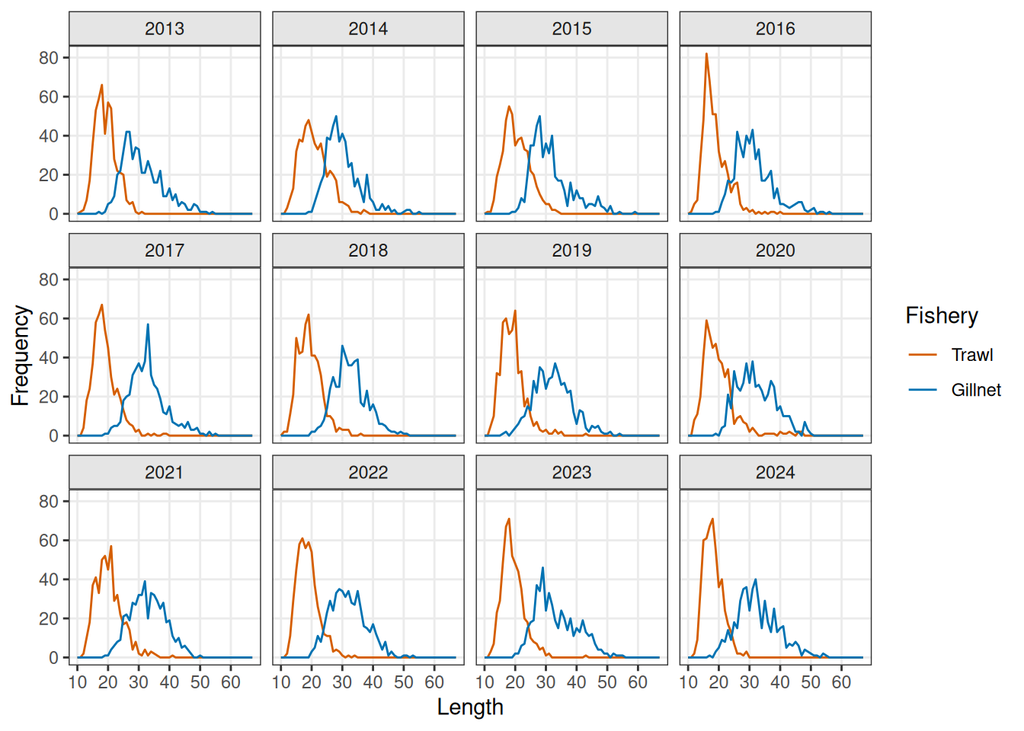

```r
plot_lfd(lfd)
```

Each panel is a year, each colour a gear. Check that the compositions look plausible: one main mode per gear, no sudden shifts between years, no fish far beyond the expected maximum length.

## 2.4 Step 4: life history

Growth, natural mortality, maturity and the length-weight relationship are given as an `FLPar`:

| Parameter | Meaning |
| --- | --- |
| `linf`, `k` | von Bertalanffy asymptotic length and growth rate |
| `M` | natural mortality (per year) |
| `L50` | length at 50% maturity |
| `a`, `b` | weight-length relationship $W = aL^b$ (here weight in kg for length in cm) |

```r
lhpar <- FLPar(linf = 55.7, k = 0.08, M = 0.162, L50 = 31.1859,
               a = 0.004721956 / 1000, b = 3.146168)
```

## 2.5 Step 5: the stock object and natural mortality

`stocklen()` combines the length data and the life history into an `FLStockLen` object with weight, maturity and natural mortality at length. `m_model` sets how natural mortality changes with length:

| `m_model` | M at length |
| --- | --- |
| `"constant"` | the same M at all lengths (default choice) |
| `"inverse"` | $M\,L_{ref}/L$, higher for small fish; needs `reflen` |
| `"Lorenzen"` | allometric, decreasing with weight |
| `"Gislason"` | empirical, depending on length and Linf |

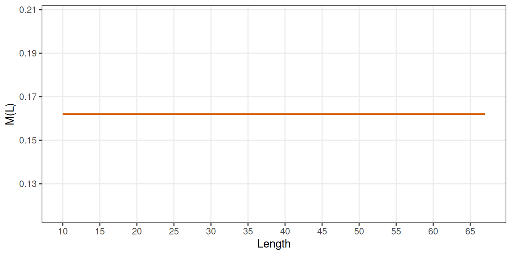

```r
stklen <- stocklen(lfd, lhpar, m_model = "constant")
plot_m(stklen)
```

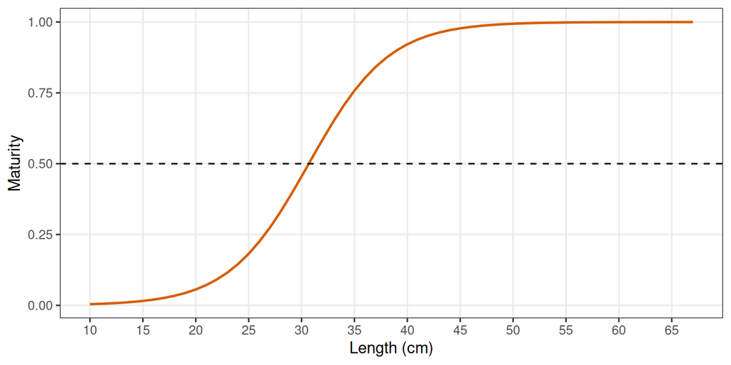

```r
plot_mat(stklen)
```

Start with `"constant"` unless there is a biological reason for a length-dependent M.

## 2.6 Step 6: fit the model

Two inputs are always needed besides the data and the stock object, both with one entry per gear in the order of `names(lfd)` (here Trawl, Gillnet):

- **`sel_fun`**: the shape of each gear’s selectivity. `"logistic"` for gears that keep catching the largest fish (asymptotic, e.g. most trawls and longlines); `"dsnormal"` (double-sided normal) for gears that catch mostly intermediate sizes and fewer large fish (dome-shaped, e.g. gillnets with one mesh size, or fleets fishing where large fish are scarce). Here the trawl catches small fish and few large ones, the gillnet the larger fish.
- **`catch_by_gear`**: the share of the total catch taken by each gear, e.g. `c(0.7, 0.3)` for 70% and 30%. It tells the model how to split F between the gears; FLicc matches it to the predicted catch **in weight**, so the shares of the landings in tonnes can be used directly.

```r
fit1 <- fiticc(lfd, stklen,
               sel_fun = c("dsnormal", "logistic"),
               catch_by_gear = c(0.7, 0.3))
```

All other settings are at their defaults: growth and M fixed at the input values, a multinomial likelihood on the counts as they are, and a random walk on F over the years.

## 2.7 Step 7: check and plot the results

First check that the fit converged: all lines should show `passed = TRUE`.

```r
flicc_convergence(fit1)
```

```
#>                              check              value passed
#> 2           Gradient is acceptable            0.01026  FALSE
#> 3     Hessian is positive definite               TRUE   TRUE
#> 4        Standard errors available 29 / 29 parameters   TRUE
#> 5 Hessian eigenvalues are positive              31.15   TRUE
#>                                            interpretation
#> 2                 The fit is close to a stationary point.
#> 3                    The model curvature is well behaved.
#> 4      Uncertainty could be estimated for all parameters.
#> 5 No flat or negative curvature directions were detected.
```

The fitted (lines) against the observed (bars) length compositions, by gear:

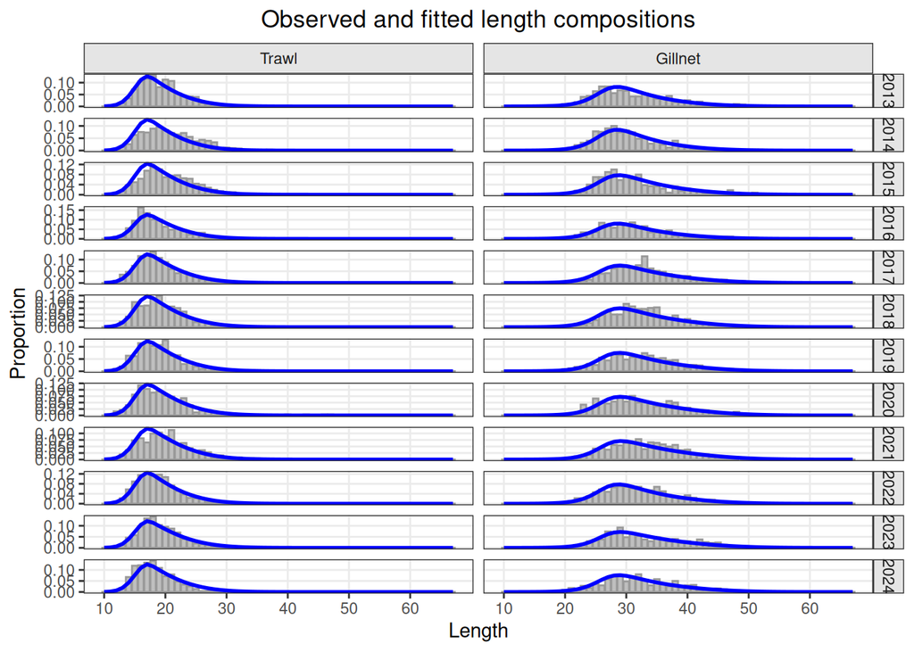

```r
plot_len(fit1, by_gear = TRUE)
```

The estimated selectivity of each gear:

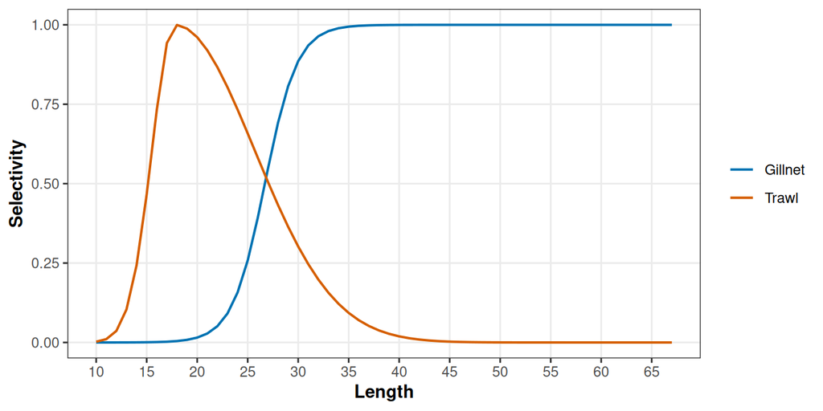

```r
plot_sel(fit1)
```

The spawning potential ratio (SPR) by year with its 95% interval, and the value in the last year. SPR is the spawning output per recruit at the estimated F relative to the unfished state; 40% is a common target.

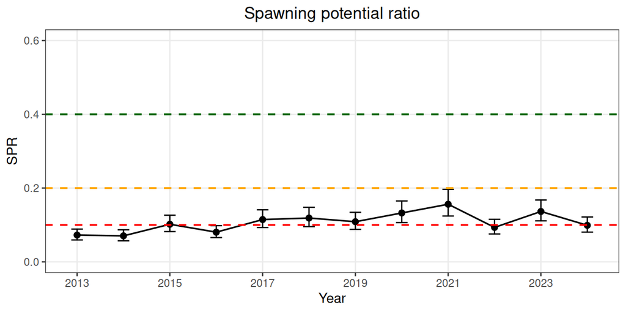

```r
plot_spr(fit1, ci = TRUE)
```

```r
sprcur_flicc(fit1)
```

```
#> [1] 0.09900769
```

That is a first assessment. Before using it, work through the checks of the following sections, in particular the effective sample size (section *Effective sample size*): the raw counts used here usually overstate the information in the data, which makes the intervals too narrow. The reference fit used in the rest of this guide differs from `fit1` only in that respect (ESS 200 per gear and year, Dirichlet-multinomial likelihood).

# 3 Workflow and defaults

1. **Data**: length frequencies by gear as `FLQuants` (Quick start); check sample sizes, gaps and the tail.
2. **Effective sample size**: rescale the counts to the information they carry.
3. **Life history**: `FLPar` and `stocklen()`; check Linf against the largest fish.
4. **Fit**: `fiticc()`; check convergence, residuals, selectivity and retrospective consistency.
5. **Status**: SPR, Fspr, steepness-corrected biomass, length-based indicators.
6. **Uncertainty**: sensitivity runs (selectivity dome, CVL, Linf, tail cut).
7. **Management**: `flicc.sa()` and harvest control rules in an MSE.

A plain `fiticc()` call uses the GTG population model, a multinomial likelihood, fixed growth (Linf, CVL) and natural mortality, and a random walk on log F with its standard deviation fixed at `sigmaF = 0.3`. These defaults are fast and stable; every other option is a deliberate change.

# 4 Length-frequency data

## 4.1 Structure

```r
data("alfonsino")
lfd <- FLQuantLen(lfd_long_to_wide(as.data.frame(lfd_alfonsino)), unit = "cm", midL = FALSE)
names(lfd)
```

```
#> [1] "Trawl"   "Gillnet"
```

```r
range(as.numeric(dimnames(lfd[[1]])$len)); range(as.numeric(dimnames(lfd[[1]])$year))
```

```
#> [1] 10 67
#> [1] 2013 2024
```

`FLQuantLen()` takes a wide table (`lfd_long_to_wide()` converts a long one) with columns for length, year, gear and counts; `midL = FALSE` means lengths are lower bin boundaries. Bins must be equally spaced and identical across gears and years (`complete_lfd_bins()` fills gaps with zeros).

## 4.2 Check 1: sample size by year and gear

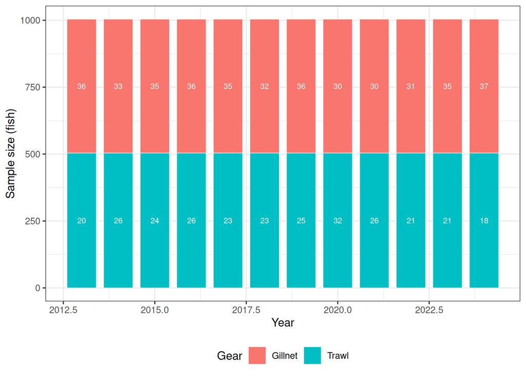

| **Why** | The information in a composition depends on how many independent samples (trips, hauls, landings) it comes from, not only on the number of fish. |
| --- | --- |
| **Look for** | Gear-years with very few fish or few occupied bins (labels), years where one gear is missing, strong changes in the gear mix between years. |
| **Red flags** | Gear-years with < 50 fish or < 10 occupied bins; a gear present only in some years; combined sample size dominated by one gear in some years and another in others. |
| **Action** | Set effective sample sizes per gear (section *Effective sample size*); consider dropping or pooling very poor gear-years; check that `catch_by_gear` reflects the catch, not the sampling, split. |

```r
plot_lfdn(lfd)
```

## 4.3 Check 2: consistency of the compositions

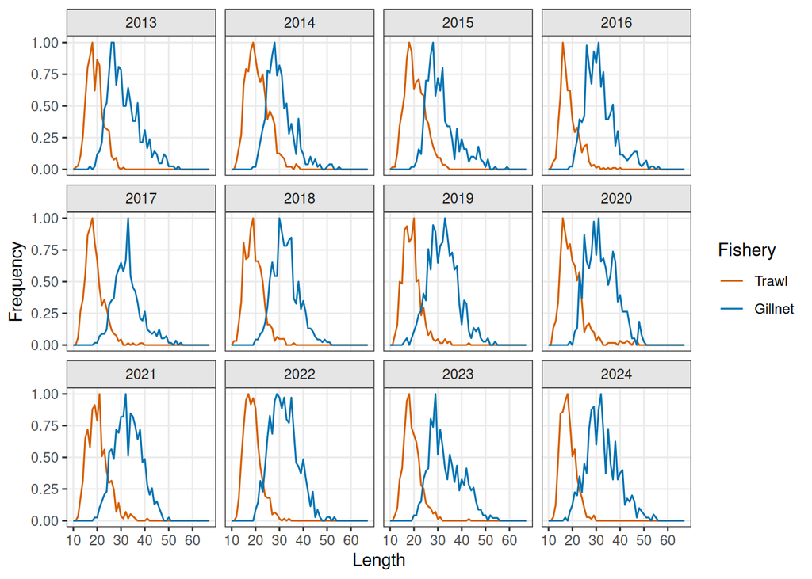

| **Look for** | Stable shapes and modes between adjacent years; similar left limbs within a gear (selectivity is assumed constant over time). |
| --- | --- |
| **Red flags** | Abrupt shifts in the mode or left limb (change of gear, mesh, market sorting or sampling programme); bimodal compositions from mixing gears or areas; truncation at the right (size limits, sorting). |
| **Action** | Split gears or periods with different selectivity; restrict `years`; investigate sampling before modelling around it. |

```r
plot_lfd(lfd, type = "relmax")
```

## 4.4 Check 3: the largest fish

```r
linf_in <- 55.7
sapply(lfd, function(x) {
  L <- as.numeric(dimnames(x)$len); n <- apply(x@.Data, 1, sum)
  c(max_length = max(L[n > 0]), pct_ge_0.9Linf = round(100 * sum(n[L >= 0.9 * linf_in]) / sum(n), 1),
    pct_ge_Linf = round(100 * sum(n[L >= linf_in]) / sum(n), 2))
})
```

```
#>                Trawl Gillnet
#> max_length        47   59.00
#> pct_ge_0.9Linf     0    0.70
#> pct_ge_Linf        0    0.03
```

| **Why** | The tail is the part of the composition most sensitive to Linf, CVL, dome-shaped selectivity and the GTG discretisation. |
| --- | --- |
| **Red flags** | More than about 1% of fish at or above the input Linf; a long thin tail far beyond Linf (misidentified species, measurement errors, other stocks). |
| **Action** | Re-examine Linf; use a tail cut (section *Tail of the length composition*) or `rob_eps`; `tail_warning = TRUE` in `settings` reports fish beyond the largest growth group. |

## 4.5 Check 4: empirical catch curves

A log-linear catch curve on the length-converted ages gives a quick, model-free view of total mortality by year and of its trend:

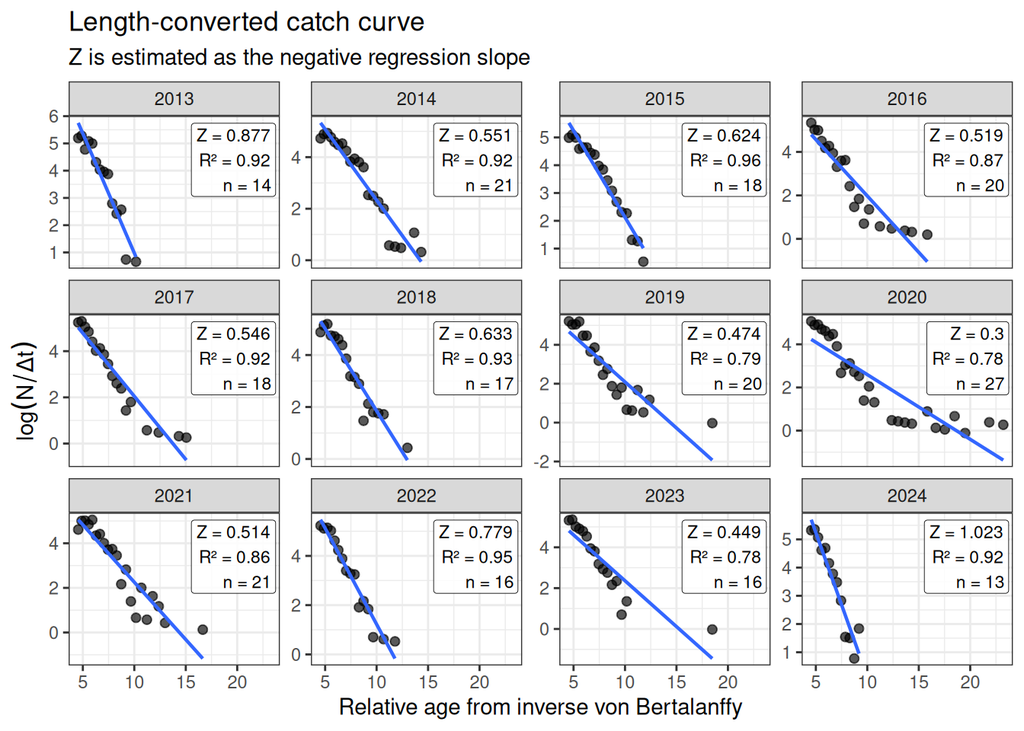

| **Look for** | Roughly linear descending limbs; a stable or smoothly changing slope (Z). |
| --- | --- |
| **Red flags** | Strongly curved descending limbs (dome-shaped selectivity, recruitment pulses), slopes jumping between years (sampling noise or changing selectivity). |
| **Action** | Consider `dsnormal` selectivity or a tail cut; expect noisy annual F and keep the random walk. |

```r
lhpar <- FLPar(linf = 55.7, k = 0.08, M = 0.162, L50 = 31.1859,
               a = 0.004721956 / 1000, b = 3.146168)
plot_zlcc(lfd$Trawl, lhpar)
```

# 5 Effective sample size

## 5.1 How the sample size enters the likelihood

For gear $g$ in year $y$, with observed counts $y_{g,y,l}$, total $n_{g,y} = \sum_l y_{g,y,l}$ and predicted proportions $\pi_{g,y,l}$:

- **Multinomial** (`obs_model = "mn"`): $-\log L = -\sum_l y_{g,y,l} \log \pi_{g,y,l}$. The weight of a composition is proportional to $n_{g,y}$.
- **Negative binomial** (`"nb"`): counts with mean $n_{g,y}\pi_{g,y,l}$ and overdispersion $\phi$ (estimated), variance $\mu + \mu^2/\phi$.
- **Dirichlet-multinomial** (`"dm"`): the compositions are drawn from a Dirichlet with mean $\pi_{g,y}$ and precision $\alpha_0$; in FLicc $\alpha_0 = n_{g,y}$. The variance of the proportions is inflated by $(n + \alpha_0)/(1 + \alpha_0) \approx 2$, so a DM fit at sample size $n$ carries about the information of a multinomial with $n/2$. Its log-gamma form also penalises single-bin misfits less than the multinomial, which makes it more robust with messy real data.

`lfdess(lfd, ess.g)` rescales each gear-year to the given effective sample size (ESS), keeping the proportions; empty gear-years stay empty.

## 5.2 Why very large sample sizes do harm

Measured fish are not independent: fish from one haul or trip share its length structure. Raw counts (often thousands) therefore overstate the information by an order of magnitude. With an overstated sample size:

- the likelihood is dominated by small structural misfits (growth model, binning, selectivity shape) rather than the signal, so estimates and their standard errors are overconfident;
- log-likelihood differences between alternative assumptions become huge, so AIC weights across an ensemble collapse onto a few draws and likelihood profiles become jagged or multimodal;
- any discrete effect (a fish entering or leaving the range of the largest growth group) is multiplied by $n$.

## 5.3 Choosing the effective sample size

Empirically, ESS of about 150-200 per gear-year has given the most stable assessments and ensemble profiles, and 1000 or more behaved poorly in Monte-Carlo profiling. Practical rules:

- Base ESS on the number of independent sampling units (trips, hauls, vessels) where known, e.g. a few fish-equivalents per unit; otherwise start at 150-200 per gear-year and test 100 and 300.
- Use the same ESS for gears of similar sampling quality; reduce it for gears with few trips.
- Prefer `obs_model = "dm"` with real data; remember it halves the nominal ESS.
- Never fit raw counts of several thousand fish per year without rescaling.

The demonstration below fits the alfonsino data at five effective sample sizes (`ess_values`), once with the multinomial and once with the Dirichlet-multinomial, and once more with the raw counts. `lfdess()` rescales the compositions to the given ESS; `Map()` runs one fit per value. For each fit the table shows the last-year SPR (`sprcur_flicc()`), its standard error on the log scale (from `spr_ci_flicc()`) and the largest absolute gradient at the optimum.

```r
sel_fun <- c("dsnormal", "logistic")
cbg <- c(0.7, 0.3)
stklen <- stocklen(lfd, lhpar, m_model = "constant")

ess_values <- c(50, 100, 200, 500, 1000)

# multinomial: one fit per ESS
fits_mn <- Map(function(ess) {
  fiticc(lfdess(lfd, ess.g = ess), stklen, sel_fun = sel_fun, catch_by_gear = cbg,
         settings = list(CVL = 0.1, obs_model = "mn"))
}, ess_values)
names(fits_mn) <- paste0("mn_", ess_values)

# Dirichlet-multinomial: one fit per ESS
fits_dm <- Map(function(ess) {
  fiticc(lfdess(lfd, ess.g = ess), stklen, sel_fun = sel_fun, catch_by_gear = cbg,
         settings = list(CVL = 0.1, obs_model = "dm"))
}, ess_values)
names(fits_dm) <- paste0("dm_", ess_values)

# raw counts (no rescaling)
fit_raw_mn <- fiticc(lfd, stklen, sel_fun = sel_fun, catch_by_gear = cbg,
                     settings = list(CVL = 0.1, obs_model = "mn"))
fit_raw_dm <- fiticc(lfd, stklen, sel_fun = sel_fun, catch_by_gear = cbg,
                     settings = list(CVL = 0.1, obs_model = "dm"))
raw_n <- round(mean(quantSums(lfd[["Trawl"]])))   # fish per year, trawl

fits_mn <- c(fits_mn, raw = list(fit_raw_mn))
fits_dm <- c(fits_dm, raw = list(fit_raw_dm))

# standard error of log SPR in the last year
se_logspr <- function(fit) tail(spr_ci_flicc(fit)$se_log, 1)
ess_table <- data.frame(
  ESS        = c(ess_values, paste0("raw (~", raw_n, ")")),
  SPR_mn     = round(sapply(fits_mn, sprcur_flicc), 3),
  SPR_dm     = round(sapply(fits_dm, sprcur_flicc), 3),
  se_mn      = round(sapply(fits_mn, se_logspr), 3),
  se_dm      = round(sapply(fits_dm, se_logspr), 3),
  maxgrad_dm = signif(sapply(fits_dm, function(fit) fit$max_gradient), 2),
  row.names  = NULL)
ess_table
```

```
#>          ESS SPR_mn SPR_dm se_mn se_dm maxgrad_dm
#> 1         50  0.111  0.276 0.269 0.284     0.0013
#> 2        100  0.108  0.182 0.206 0.236     0.0046
#> 3        200  0.104  0.136 0.155 0.190     0.0099
#> 4        500  0.099  0.108 0.105 0.137     0.1300
#> 5       1000  0.094  0.096 0.079 0.105     0.0370
#> 6 raw (~504)  0.099  0.107 0.105 0.137     0.0050
```

The alfonsino example has about 504 fish per gear-year, so its raw counts are moderate; with the thousands of fish per year common in market sampling the effects above are much stronger, also for the AIC weights of a Monte-Carlo ensemble.

SPR with 95% intervals for the Dirichlet-multinomial at ESS 50, 200 and 1000 and for the raw counts:

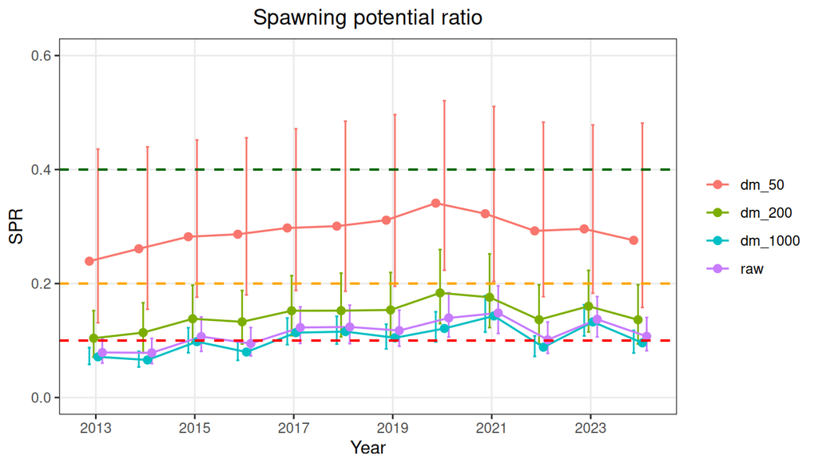

```r
plot_spr(fits_dm[c("dm_50", "dm_200", "dm_1000", "raw")], ci = TRUE)
```

*Open issue*: estimating the DM precision (overdispersion) instead of fixing $\alpha_0 = n$ would let the data choose their own weight; this is planned.

# 6 Missing data

FLicc handles missing gear-years directly: a gear-year without samples (all zero counts) contributes nothing to the composition likelihood, and its F is informed by the random walk from neighbouring years and by the catch-share constraint.

```r
lfd200 <- lfdess(lfd, ess.g = 200)
lfd_miss <- lfd200
lfd_miss[["Gillnet"]][, c("2016", "2017")] <- 0
lfd_miss[["Trawl"]][, "2020"] <- 0
fit200 <- fiticc(lfd200, stklen, sel_fun = sel_fun, catch_by_gear = cbg,
                 settings = list(CVL = 0.1, obs_model = "dm"))
fit_miss <- fiticc(lfd_miss, stklen, sel_fun = sel_fun, catch_by_gear = cbg,
                   settings = list(CVL = 0.1, obs_model = "dm"))
flicc_convergence(fit_miss)
```

```
#>                              check              value passed
#> 2           Gradient is acceptable           0.004424   TRUE
#> 3     Hessian is positive definite               TRUE   TRUE
#> 4        Standard errors available 29 / 29 parameters   TRUE
#> 5 Hessian eigenvalues are positive              5.247   TRUE
#>                                            interpretation
#> 2                 The fit is close to a stationary point.
#> 3                    The model curvature is well behaved.
#> 4      Uncertainty could be estimated for all parameters.
#> 5 No flat or negative curvature directions were detected.
```

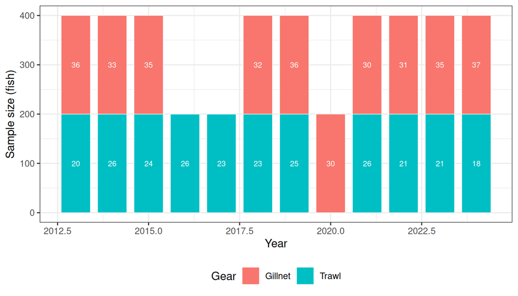

```r
plot_lfdn(lfd_miss)
```

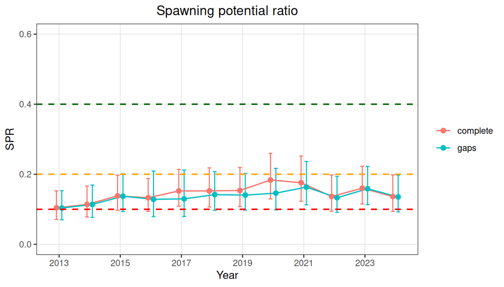

```r
plot_spr(list(complete = fit200, gaps = fit_miss), ci = TRUE)
```

Guidelines:

| Situation | Handling |
| --- | --- |
| a gear missing in some years | keep the zeros; the random walk bridges them (intervals widen) |
| all gears missing in a year | leave the year in (F interpolated) or restrict `years` |
| long gaps or a gear only at the start or end | consider fitting the gear’s period separately; selectivity is assumed constant |
| no random walk (`prior_sigmaF = FALSE`) | **avoid with gaps**: F of a gear-year without data is not identified |
| `by_year = TRUE` | fits only years with data; selectivity per year |
| catch by gear missing | use the average split; it only enters through the catch-share constraint |

# 7 Life history and the stock object

```r
stklen
```

```
#> An object of class "FLStockLen"
#>
#> Name: FLicc stocklen
#> Description:
#> Quant: len
#> Dims:  len   year    unit    season  area    iter
#>  58  12  1   1   1   1
#>
#> Range:  min  max minyear maxyear minfbar maxfbar
#>  10  67  2013    2024    10  67
```

`stocklen(lfd, lhpar, m_model)` builds the length-based stock object: weight $W(L) = aL^b$, maturity as a logistic ogive with `L50` and `L95` (default `L95 = L50 + 0.2 Linf`), and natural mortality at length:

| `m_model` | $M(L)$ |
| --- | --- |
| `"constant"` | $M$ |
| `"inverse"` | $M\, L_{ref}/L$ |
| `"Lorenzen"` | Lorenzen weight-based, scaled to $M$ at `reflen` |
| `"Gislason"` | Gislason et al. (2010) from $L$, $L_\infty$, $k$ |

The length model uses $M/k$ (and $Z/k$): what matters is the ratio, so k and M uncertainty should be considered jointly (as in `mc_flicc()`).

## 7.1 Check 5: life-history inputs

| **Look for** | Linf close to the largest regularly observed lengths (Check 3); M/k near the life-history invariant range (often 1-2); L50 below the modal length of the main gear. |
| --- | --- |
| **Red flags** | Linf well below the largest fish (many fish beyond Linf) or far above it; Linf from another region or sex; M/k outside 0.5-3 without justification. |
| **Action** | Linf is the dominant sensitivity (simulation: a 10% error shifts SPR by +75% / -30%); run Linf sensitivities and include Linf in the ensemble. |

# 8 Selectivity

## 8.1 Functions and parameterisation

Selectivity is specified per gear in `sel_fun` and estimated on a scale relative to Linf (log parameters $\theta$), so starting values and priors are scale-free. With the estimated Linf:

**Logistic** (`"logistic"`):
$$S(L) = \left[1 + \exp\left(-\ln 19\,\frac{L - L_{50}}{L_{95} - L_{50}}\right)\right]^{-1},
\quad L_{50} = e^{\theta_1} L_\infty,\; L_{95} - L_{50} = e^{\theta_2} L_\infty .$$

**Double-sided normal** (`"dsnormal"`, dome):
$$S(L) = \exp\left[-\frac{(L - L_{mode})^2}{2\sigma^2}\right],\quad
\sigma = \begin{cases}\sigma_L & L < L_{mode}\\ \sigma_R & L \ge L_{mode}\end{cases},
\quad L_{mode} = e^{\theta_1}L_\infty,\; \sigma_L = e^{\theta_2}L_\infty,\; \sigma_R = e^{\theta_3}L_\infty .$$

**Normal** (`"normal"`): as above with $\sigma_L = \sigma_R$.

Starting values: the mode (or L50) at the gear’s observed modal length, spreads of 0.1 Linf. Selectivity is evaluated at bin mid-points and is constant over time.

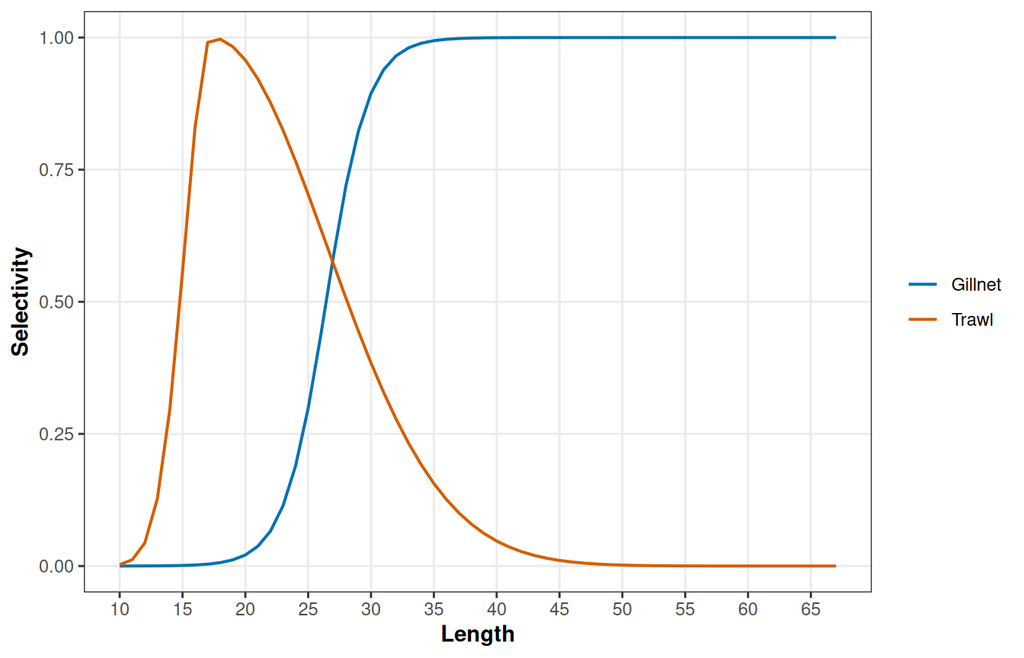

```r
plot_sel(fit200)
```

```r
selpars_flicc(fit200)
```

```
#> An object of class "FLPars"
#> [[1]]
#> An object of class "FLPar"
#> params
#>  mode   lsd   rsd
#> 17.79  2.11  9.19
#> units:  cm
#>
#> [[2]]
#> An object of class "FLPar"
#> params
#> SL50 SL95
#> 26.9 31.8
#> units:  cm
#>
#> Slot "names":
#> [1] "Trawl"   "Gillnet"
#>
#> Slot "desc":
#> character(0)
#>
#> Slot "lock":
#> [1] FALSE
```

## 8.2 Fixing selectivity parameters

`sel_fixed` fixes parameters on the length scale by gear, e.g. from mesh experiments:

```r
fiticc(lfd200, stklen, sel_fun = sel_fun, catch_by_gear = cbg,
       settings = list(CVL = 0.1, obs_model = "dm"),
       sel_fixed = list(Gillnet = list(SL50 = 30, SL95 = 34)))   # logistic
# dsnormal: list(mode = 24, lsd = 3, rsd = 1000)  (rsd = 1000: flat right limb)
# normal:   list(mode = 24, sd = 4)
```

## 8.3 Exploring selectivity shapes

`plot_selfun()` draws a selectivity function for a range of parameter values, over the observed composition of a gear and with reference lengths. It helps to choose values for `sel_fixed` and the dome scenarios below:

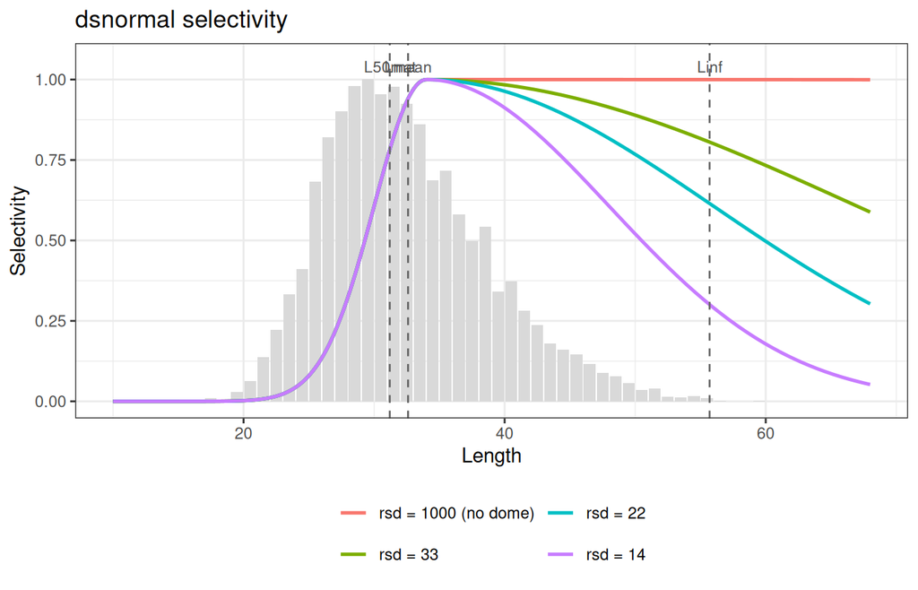

```r
gn <- lfd[["Gillnet"]]
Lmid_g <- as.numeric(dimnames(gn)$len) + 0.5
Lmean_g <- round(sum(Lmid_g * apply(gn@.Data, 1, sum)) / sum(gn@.Data), 1)
ref_L <- c(L50mat = 31.2, Lmean = Lmean_g, Linf = 55.7)
plot_selfun("dsnormal", list(mode = 34, lsd = 4, rsd = c(1000, 33, 22, 14)), lfd = gn, ref = ref_L)
```

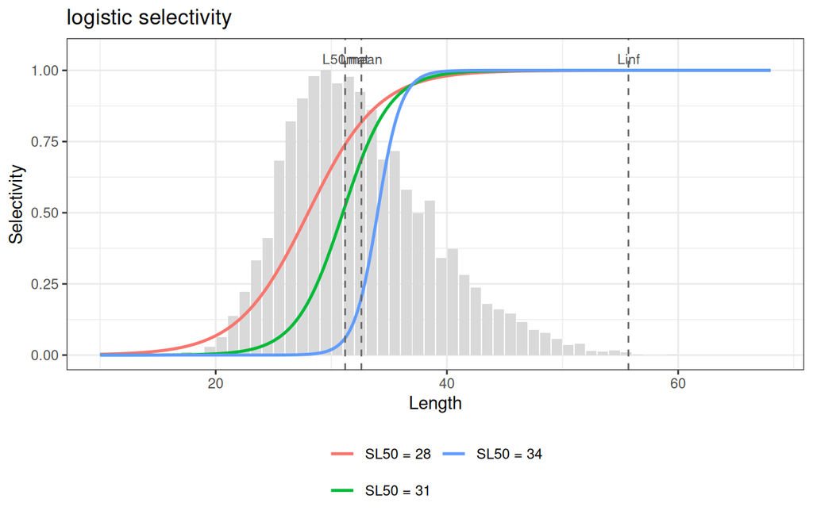

```r
plot_selfun("logistic", list(SL50 = c(28, 31, 34), SL95 = 37), lfd = gn, ref = ref_L)
```

A double-sided normal with a very large right-hand SD (`rsd = 1000`) has a flat right limb, i.e. no dome; smaller values give mild (about 0.6 Linf), moderate (0.4 Linf) and strong (0.25 Linf) doming. `sel_curve_flicc()` returns the values of a curve.

## 8.4 Dome sensitivity: a recommended standard run

Slight doming (large fish less selected or less available) is hard to detect from length data, and an unmodelled dome is read as higher F. A sensitivity over fixed dome shapes is therefore recommended for every gear assumed logistic. `dome_sens_flicc()` refits the model with that gear as a double-sided normal whose right-hand SD is fixed at a sequence of values (default `c(1000, 0.6, 0.4, 0.25) x Linf`); the mode and left-hand SD are estimated, all other settings and data as in the base fit.

```r
ds <- dome_sens_flicc(fit200, gear = "Gillnet")
ds$table
```

```
#>   scenario    rsd conv    logLik      AIC SPR_last   Fspr Fap_last dAIC
#> 1     base     NA    0 -14380.78 28819.56    0.136 0.1114   0.2570 5.26
#> 2  rsd1000 1000.0    0 -14378.15 28814.30    0.134 0.1107   0.2581 0.00
#> 3  rsd33.4   33.4    0 -14378.17 28814.34    0.144 0.1142   0.2545 0.04
#> 4  rsd22.3   22.3    0 -14378.41 28814.81    0.159 0.1190   0.2485 0.51
#> 5  rsd13.9   13.9    0 -14382.76 28823.53    0.212 0.1323   0.2285 9.23
```

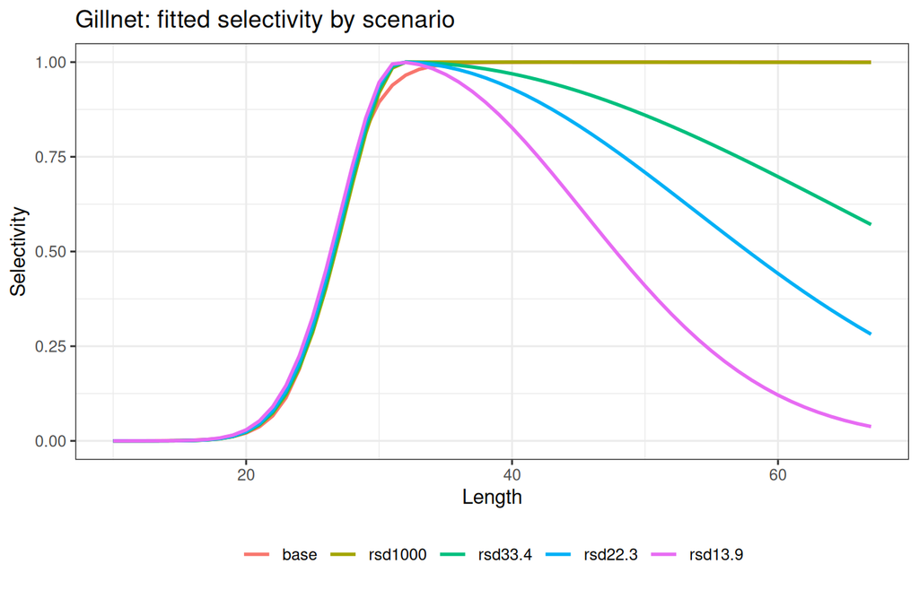

```r
plot_dome_sens(ds)
```

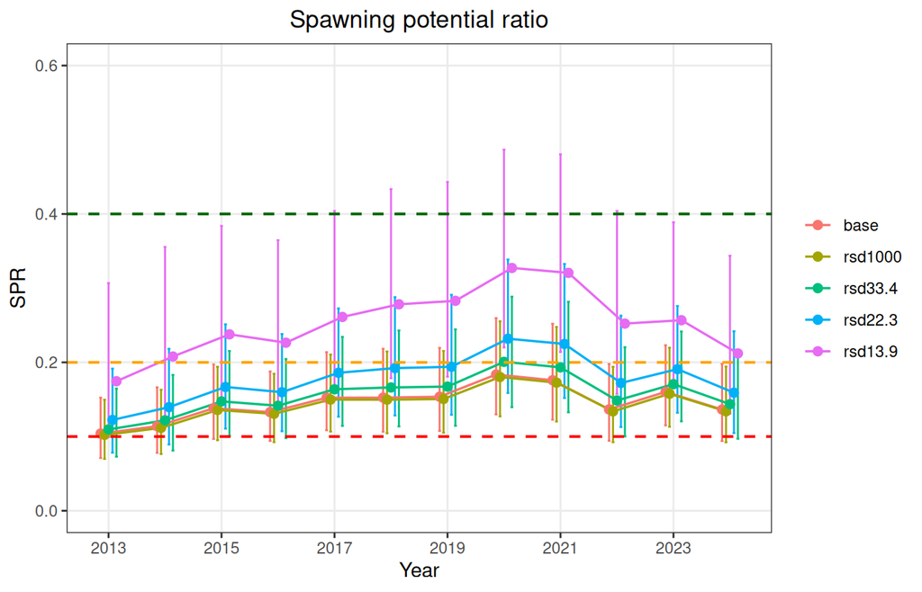

```r
plot_dome_sens(ds, "spr", ci = TRUE)
```

The run with `rsd = 1000` reproduces the logistic base fit (SPR 0.134 vs 0.136), which is the check that the scenarios are comparable. For the gillnet, no, mild and moderate domes fit equally well (dAIC 0, 0.04, 0.51), while the strong dome is worse (dAIC 9.23). The data therefore cannot tell whether large fish are fully selected or mildly less so, and over that range the last-year SPR goes from 0.134 to 0.159. Read the table as a sensitivity, not a model selection: report the range of status across the domes the data cannot reject. With a tail cut the scenarios differ less, because the bins where the dome acts are excluded:

```r
fit200_cut <- fiticc(lfd200, stklen, sel_fun = sel_fun, catch_by_gear = cbg,
                     settings = list(CVL = 0.1, obs_model = "dm", tail_cut = 47))
ds_cut <- dome_sens_flicc(fit200_cut, gear = "Gillnet", se = FALSE)
data.frame(scenario = ds$table$scenario, SPR_no_cut = ds$table$SPR_last,
           SPR_cut47 = ds_cut$table$SPR_last)
```

```
#>   scenario SPR_no_cut SPR_cut47
#> 1     base      0.136     0.124
#> 2  rsd1000      0.134     0.120
#> 3  rsd33.4      0.144     0.126
#> 4  rsd22.3      0.159     0.135
#> 5  rsd13.9      0.212     0.161
```

Here the cut narrows the range across no to moderate doming from 0.134-0.159 to 0.12-0.135.

The sensitivity is meant for gears assumed asymptotic. For a gear already fitted as a dome (here the trawl, estimated right-hand SD about 9.2 cm), fixing a wide right-hand SD forces a shape the data reject, which shows as very large dAIC.

## 8.5 Choosing selectivity

- Use logistic unless gear knowledge (gillnet mesh, hook size, availability of large fish) supports a dome.
- A dome fitted without support absorbs a shortage of large fish that may come from F; SPR then becomes optimistic.
- Several gears sampling different length ranges make domes more identifiable.
- A tail cut (section *Tail of the length composition*) reduces the cost of an unmodelled mild dome (*simulation*: a strong dome fitted as logistic, -17% bias in SPR; with a cut at 0.8 Linf, +1%).
- Always run the dome sensitivity for gears assumed logistic, and report it.

## 8.6 Check 6: selectivity plausibility

| **Look for** | Ascending limbs consistent with the gear and the left limb of the compositions; domes only where expected. |
| --- | --- |
| **Red flags** | Very narrow domes; $\sigma_R$ at very small values for a gear expected to be logistic; L50 below the smallest sampled fish. |
| **Action** | Compare logistic and dome by AIC and by status; fix parameters from external information; use a tail cut. |

# 9 Model

## 9.1 Fishing mortality and total mortality

$F_{g,y}(L) = F_{g,y} S_g(L)$, $Z_y(L) = M(L) + \sum_g F_{g,y}(L)$. Gear shares of F are informed by `catch_by_gear` through a soft constraint on the predicted catch shares in weight (`catch.sd`, default 0.05):
$$\log\frac{\hat C^w_{g,y}}{\hat C^w_{G,y}} \sim N\!\left(\log\frac{c_{g,y}}{c_{G,y}},\ \texttt{catch.sd}^2\right),
\qquad \hat C^w_{g,y} = \sum_L C_{g,y}(L)\, W(L),$$
where $c_{g,y}$ is `catch_by_gear` and $G$ the last gear. The predicted shares are in `fit$obj$report()$catch_share`.

## 9.2 Expected catch and length composition

FLicc separates the **population model** (expected numbers at length under growth, M, F and selectivity) from the **observation model** (the likelihood that links the observed counts to the expected composition), so either can be changed without the other. With $N_i$ the expected number of fish entering length bin $i$, the expected catch of gear $g$ in bin $i$ is
$$C_{i,g} = \frac{F_{i,g}}{Z_i}\left(N_i - N_{i+1}\right), \qquad Z_i = M_i + \sum_g F_{i,g},$$
and the expected composition of gear $g$ is $\pi_{i,g} = C_{i,g} / \sum_i C_{i,g}$.

## 9.3 Population model

`pop_model = "gtg"` (default, as LBSPR): growth-type groups $L_{\infty,h} = L_\infty(1 + \mathrm{CVL}\, z_h)$, $z_h$ on `seq(-maxsd, maxsd, length = ngtg)` (13 groups, `maxsd = 2`), weights $\omega_h \propto \phi(z_h)$. Within a group, survival across bin $i$ follows from the time needed to grow through it under von Bertalanffy growth:
$$N_{i+1,h} = N_{i,h}\left(\frac{L_{\infty,h} - L_{i+1}}{L_{\infty,h} - L_i}\right)^{Z_i/k},
\qquad N_i = \sum_h \omega_h N_{i,h}.$$

`pop_model = "gamma"` follows fishblicc: Linf is gamma-distributed among individuals, and the numbers at length integrate survival over that distribution,
$$N_i = \int f(L_\infty)\, S_i(L_\infty)\, dL_\infty ,$$
evaluated by Gauss-Laguerre quadrature (slower). Both are equilibrium models: each year is explained by the equilibrium at that year’s F (section *Lag under changing F* on the consequences).

## 9.4 Observation model

For gear $g$ in year $y$, with counts $\mathbf y_{g,y}$ and total $n_{g,y}$:

- `obs_model = "mn"` (default): $\mathbf y_{g,y} \sim \text{Multinomial}(n_{g,y}, \boldsymbol\pi_{g,y})$.
- `"nb"`: $y_{i,g,y} \sim \text{NB}(\mu, \phi)$ with $\mu = n_{g,y}\pi_{i,g,y}$ and $\text{Var} = \mu + \mu^2/\phi$; $\phi$ is estimated.
- `"dm"`: $\mathbf y_{g,y} \sim \text{Dirichlet-multinomial}(n_{g,y}, \alpha_0 \boldsymbol\pi_{g,y})$ with $\alpha_0 = n_{g,y}$.

How the sample size enters each of them is explained in section *Effective sample size*; the three are compared on the same data in section *Population and observation models compared*.

## 9.5 Status: SPR

$$\mathrm{SPR}_y = \frac{\sum_L N_{F_y}(L) W(L) P_{mat}(L)}{\sum_L N_0(L) W(L) P_{mat}(L)} .$$

# 10 Fitting and fit checks

```r
t0 <- system.time(
  fit <- fiticc(lfd200, stklen, sel_fun = sel_fun, catch_by_gear = cbg,
                settings = list(CVL = 0.1, obs_model = "dm"))
)
t0[["elapsed"]]
```

```
#> [1] 0.662
```

```r
sigmaF_flicc(fit)
```

```
#> [1] 0.3
```

From here on, `fit` is the reference fit (Dirichlet-multinomial, ESS 200).

## 10.1 Settings

| Setting | Default | Role |
| --- | --- | --- |
| `pop_model` | `"gtg"` | `"gtg"`, `"gamma"` (`"gtg.dyn"`: development) |
| `obs_model` | `"mn"` | `"mn"`, `"nb"`, `"dm"` |
| `CVL` | 0.1 | CV of Linf among growth groups (fixed unless `CVL.sd`) |
| `ngtg`, `maxsd` | 13, 2 | GTG grid (as LBSPR) |
| `Mpow` | 0 | M/k at length $\propto (L_\infty/L)^{Mpow}$ |
| `linf.sd`, `Mk.sd`, `CVL.sd` | `NULL` | estimate with a prior around the input |
| `sigmaF` | 0.3 | random-walk SD of log F, fixed |
| `prior_sigmaF` | – | `c(mean, sd, use)`: estimate sigmaF with a prior; `FALSE`: no random walk |
| `F_re` | `FALSE` | log F as random effects (Laplace), sigmaF estimated |
| `catch.sd` | 0.05 | SD of the catch-share constraint |
| `tail_cut` | `NULL` | exclude bins with lower bound `>= tail_cut` (length) |
| `Lplus` | `NULL` | pool bins with lower bound `>= Lplus` |
| `rob_eps` | 0 | robust likelihood: $(1 - \epsilon)\pi + \epsilon/n_{bins}$ |
| `spr_ref` | 40 | SPR target(s) (%) whose Fspr is stored with the fit |
| `FM_min`, `FM_max` | 0.05, 4 | bounds on apical F/M (soft penalty) |
| `tail_warning` | `FALSE` | warn about fish beyond the largest GTG Linf |

Further arguments of `fiticc()`: `n_restart` (restarts while the gradient is large), `se = FALSE` (skip standard errors), `start` (e.g. `fit$opt$par`), `years`, `by_year`, `sel_fixed`.

## 10.2 Check 7: convergence

```r
flicc_convergence(fit)
```

```
#>                              check              value passed
#> 2           Gradient is acceptable           0.009888   TRUE
#> 3     Hessian is positive definite               TRUE   TRUE
#> 4        Standard errors available 29 / 29 parameters   TRUE
#> 5 Hessian eigenvalues are positive              6.952   TRUE
#>                                            interpretation
#> 2                 The fit is close to a stationary point.
#> 3                    The model curvature is well behaved.
#> 4      Uncertainty could be estimated for all parameters.
#> 5 No flat or negative curvature directions were detected.
```

| **Pass** | convergence code 0, maximum gradient < 0.001-0.01, positive-definite Hessian, finite standard errors. |
| --- | --- |
| **Red flags** | large gradient after restarts; non-positive-definite Hessian; parameters at bounds (F/M at `FM_min`/`FM_max`, very small selectivity spreads). |
| **Action** | more restarts (`n_restart`); restart from `fit$opt$par`; simplify selectivity (logistic, fewer gears); check sample sizes; a tail cut or `rob_eps` if the tail drives the problem. |

## 10.3 Check 8: fit to the compositions

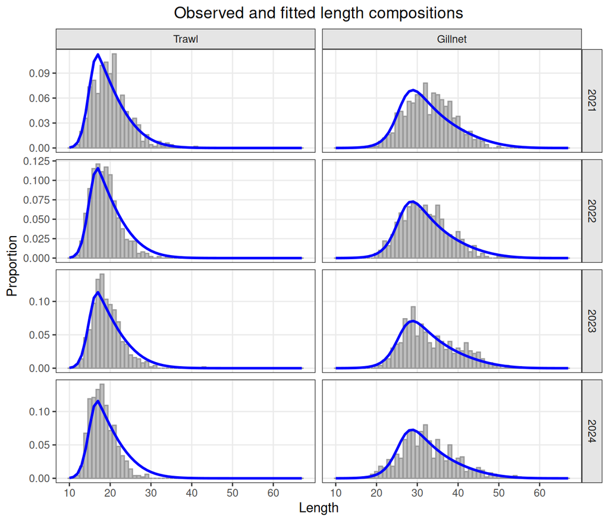

```r
plot_len(fit, by_gear = TRUE, year = 2021:2024)
```

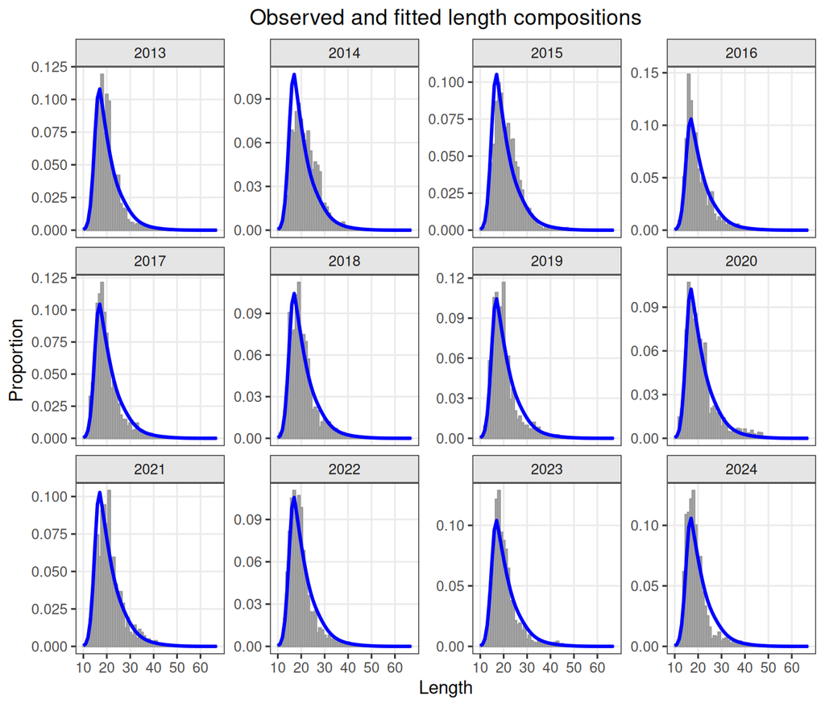

| **Look for** | Predictions through the observed modes and descending limbs in every gear. |
| --- | --- |
| **Red flags** | Systematic misfit of the left limb (selectivity), of the tail (Linf, CVL, dome), or of one gear only; the misfit changing sign between periods (time-varying selectivity or sampling). |
| **Action** | Revisit selectivity form and Linf; tail cut; split periods. |

```r
plot_len(fit)
```

## 10.4 Residual diagnostics

FLicc is an equilibrium model: each year’s composition is explained by the equilibrium at that year’s F. Strong and weak year classes growing through the compositions are therefore expected to leave patterns in the residuals. The aim of the diagnostics is not to remove these patterns but to see them and judge their size, and to separate them from misfit that a setting can fix (selectivity, Linf, tail, effective sample size).

**Residuals.** `resid_flicc()` computes residuals consistent with the likelihood of the fit (effective sample size, observation model, tail cut, plus group):

- Pearson residuals, $r = (o - n\pi)/\sqrt{V}$, with $V = n\pi(1-\pi)$ for the multinomial and the same times $(n+\alpha_0)/(1+\alpha_0)$ for the Dirichlet-multinomial. They are easy to read in bubble plots but correlated within a composition and not normal for small expected counts.
- One-step-ahead (OSA) residuals: the composition is split, along increasing length, into a sequence of conditional binomials (beta-binomials for the Dirichlet-multinomial), and each observed count is turned into a randomized quantile residual $r = \Phi^{-1}(u)$. Under a correct model they are independent standard normal (Trijoulet et al. 2023), so QQ plots and tests are valid.

```r
res_osa <- resid_flicc(fit, type = "osa")
c(mean = mean(res_osa$resid, na.rm = TRUE), sd = sd(res_osa$resid, na.rm = TRUE))
```

```
#>      mean        sd
#> 0.2295536 0.7647544
```

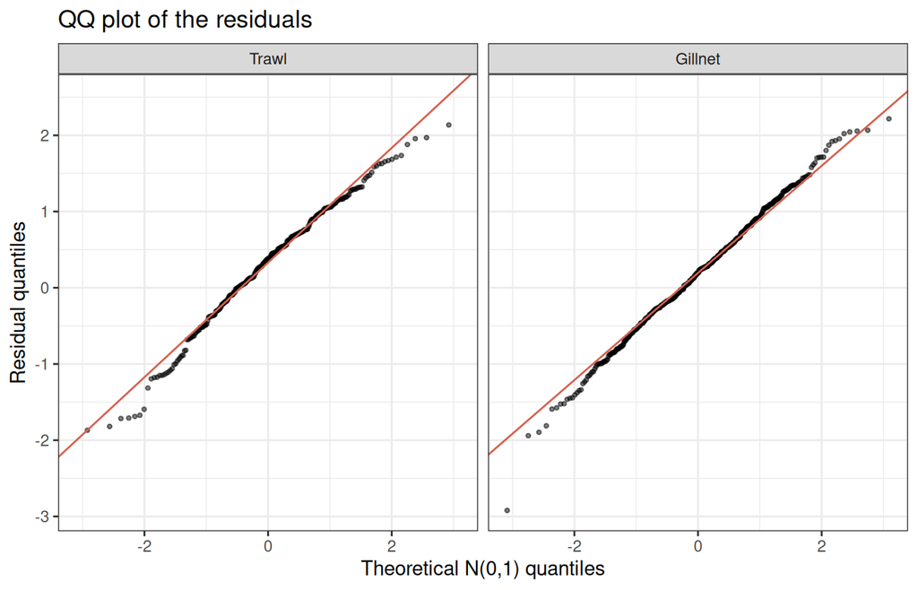

```r
plot_resid_qq(res_osa)
```

**Bubble plots.** Residuals by length and year; blue where more fish were observed than expected, red where fewer. `cohorts = TRUE` adds von Bertalanffy growth tracks of year classes (grey lines):

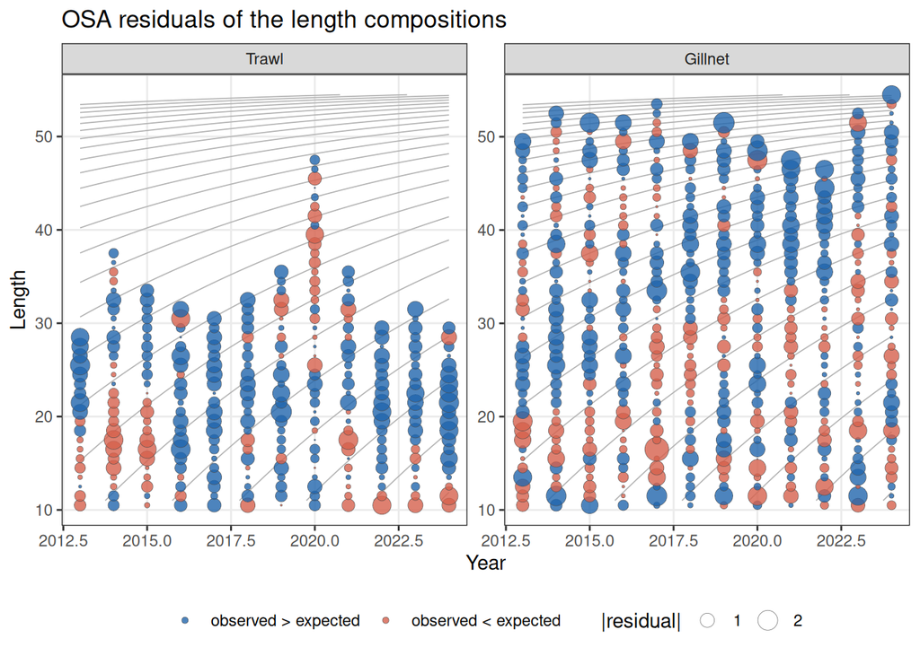

```r
plot_resid_bubble(res_osa, fit = fit, cohorts = TRUE)
```

**Mean length and runs test.** The observed mean length of each composition is compared with its expectation, standardized with the standard error implied by the observation model (Francis 2011). A runs test checks whether the residuals change sign as often as random residuals would; too few runs mean systematic structure (green background: passed; red: failed; limits at three standard deviations, as in `ss3diags` and JABBA):

```r
lmr <- lmean_resid_flicc(fit)
lmr$runs
```

```
#>            gear p_value pass sd_z
#> Trawl     Trawl   0.179 TRUE 1.80
#> Gillnet Gillnet   0.301 TRUE 0.97
```

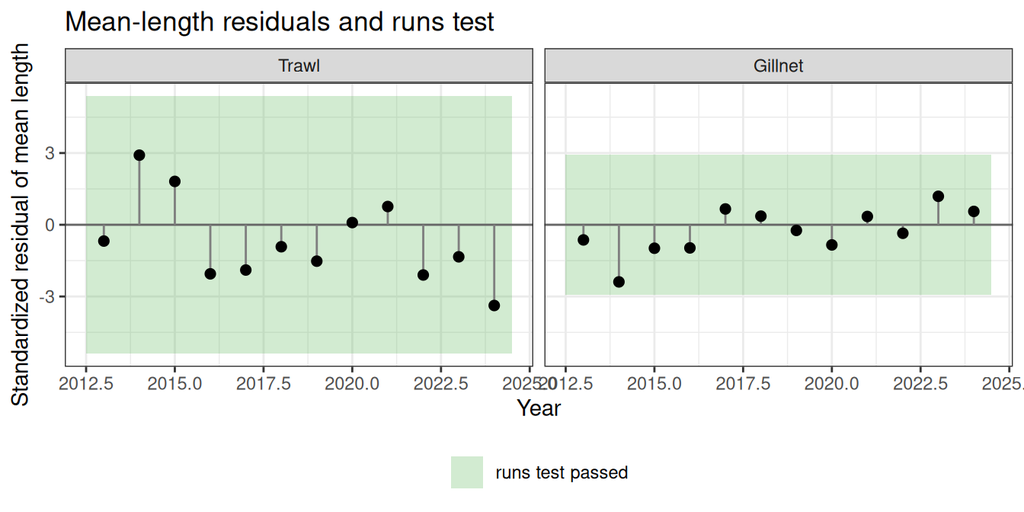

```r
lmr$plot
```

**Posterior predictive checks.** `ppc_flicc()` simulates compositions from the fitted model (at the effective sample size and with the observation model of the fit) and compares observed statistics with their predictive distribution: mean length, 95th percentile, proportion of mature fish and largest length. With `par_draws = TRUE` the parameters are also drawn from their estimated uncertainty.

```r
ppc <- ppc_flicc(fit, nsim = 300)
ppc$coverage
```

```
#>      gear  stat share_outside_95
#> 1   Trawl Lmean             0.42
#> 2 Gillnet Lmean             0.08
#> 3   Trawl   L95             0.17
#> 4 Gillnet   L95             0.00
#> 5   Trawl  Pmat             0.00
#> 6 Gillnet  Pmat             0.08
#> 7   Trawl  Lmax             0.17
#> 8 Gillnet  Lmax             0.00
```

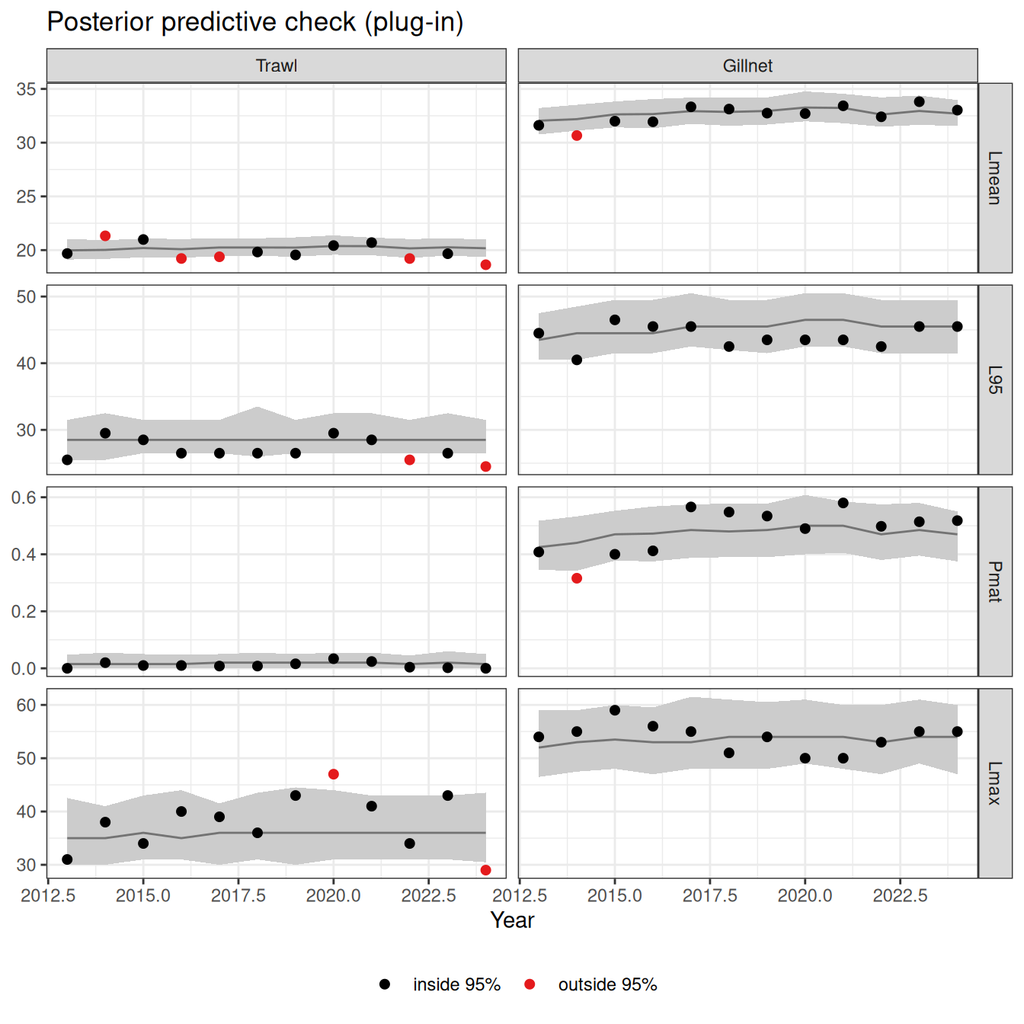

```r
ppc$plot
```

About 5% of the observed values should lie outside the 95% intervals. Many more means that the effective sample size or the observation model understate the variability of the data, so the intervals of the assessment are too narrow; far fewer means the effective sample size could be higher.

| Pattern | Likely cause | Response |
| --- | --- | --- |
| Diagonal runs of one sign along the cohort tracks; mean-length runs test failed | strong or weak year classes (expected in an equilibrium model) | report it; check that status is robust (retrospective, tail cut); do not over-fit |
| Vertical bands of one sign at the same lengths in all years | selectivity shape | logistic vs dome; dome sensitivity |
| Misfit of the largest fish in all years | Linf, CVL or doming | Linf sensitivity, tail cut |
| A change of sign between periods | change of selectivity, gear or sampling | split periods; `by_year` check |
| Many observed statistics outside the predictive intervals | ESS too high, or observation model too narrow | lower ESS; Dirichlet-multinomial |
| OSA residuals with sd well above 1 | the same | the same |

## 10.5 Check 9: retrospective consistency

The model is refitted with the last one, two and three years removed (`peels`); `Map()` runs one fit per peel. Mohn’s rho compares the terminal SPR of each peel with the SPR of the same year in the full fit.

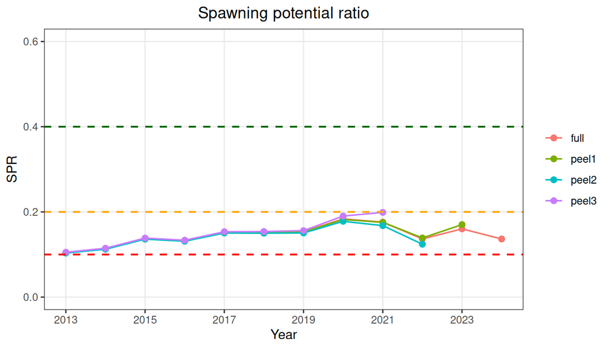

```r
yrs <- as.numeric(dimnames(lfd200[[1]])$year)
peels <- 1:3

retro <- Map(function(p) {
  fiticc(lfd200, stklen, sel_fun = sel_fun, catch_by_gear = cbg,
         settings = list(CVL = 0.1, obs_model = "dm"),
         years = head(yrs, -p), se = FALSE)
}, peels)
names(retro) <- paste0("peel", peels)
plot_spr(c(list(full = fit), retro))
```

```r
spr_full <- c(fit$report$spr)
spr_peel <- sapply(retro, sprcur_flicc)               # terminal SPR of each peel
spr_same <- spr_full[length(spr_full) - peels]        # same years in the full fit
mohn_rho <- mean((spr_peel - spr_same) / spr_same)
round(mohn_rho, 3)
```

```
#> [1] 0.034
```

| **Pass** | Mohn’s rho for SPR within about ±0.2. |
| --- | --- |
| **Red flags** | Consistent revisions in one direction (the terminal SPR is systematically revised up or down). |
| **Action** | Check for trends in selectivity or sampling; in a rebuild, an equilibrium model is expected to under-estimate SPR at the end of the series (section *Lag under changing F*). |

# 11 Fishing mortality over time

Log F by gear follows a random walk,
$$\log F_{g,y} = \log F_{g,y-1} + \varepsilon_{g,y}, \qquad \varepsilon_{g,y} \sim N(0, \sigma_F^2).$$
With selectivity $S_g(L)$ shared by all years, the model is fitted to all compositions at once; the objective is
$$-\log L = -\sum_{y} \log L_y\!\left(F_{\cdot,y}, S\right)
- \sum_{g,y>1} \log \phi\!\left(\log F_{g,y} - \log F_{g,y-1};\, 0, \sigma_F\right).$$
Compared with fitting each year on its own (as LBSPR does), this has four advantages:

- **Selectivity from all years.** The left limb of the compositions is informed by every year, so selectivity is better determined and does not absorb year-to-year sampling noise.
- **Borrowing strength.** A year with few fish is fitted close to its neighbours instead of producing an extreme F.
- **Missing years.** A year without data of a gear still gets an F, bridged by the random walk (section *Missing data*).
- **Separation of signal and noise.** $\sigma_F$ sets how much of the year-to-year change in the compositions is read as a change in F.

The price is smoothing: with small $\sigma_F$ a real change in F is spread over several years (section *Lag under changing F*). The options below differ in how $\sigma_F$ is treated.

The four options for $\sigma_F$ are fitted below to the same data (ESS 200, Dirichlet-multinomial). Only the F settings differ, so each option has its own `settings` list; `Map()` fits them in turn.

```r
f_settings <- list(
  fixed_0.3 = list(CVL = 0.1, obs_model = "dm", sigmaF = 0.3),                       # default
  prior     = list(CVL = 0.1, obs_model = "dm", prior_sigmaF = c(log(0.5), 0.3, 1)), # penalised
  F_re      = list(CVL = 0.1, obs_model = "dm", F_re = TRUE),                        # random effects
  no_RW     = list(CVL = 0.1, obs_model = "dm", prior_sigmaF = FALSE))               # no random walk

fits_F <- Map(function(set) {
  fiticc(lfd200, stklen, sel_fun = sel_fun, catch_by_gear = cbg, settings = set)
}, f_settings)

data.frame(option   = names(fits_F),
           sigmaF   = round(sapply(fits_F, sigmaF_flicc), 3),
           SPR_last = round(sapply(fits_F, sprcur_flicc), 3),
           se_log   = round(sapply(fits_F, se_logspr), 3),
           row.names = NULL)
```

```
#>      option sigmaF SPR_last se_log
#> 1 fixed_0.3  0.300    0.136  0.190
#> 2     prior  0.079    0.147  0.134
#> 3      F_re  0.053    0.148  0.119
#> 4     no_RW     NA    0.126  0.213
```

`sigmaF_flicc()` returns the fixed or estimated $\sigma_F$ (NA without a random walk). The SPR trajectories with 95% intervals, and the apical F by year (`report$Fap`):

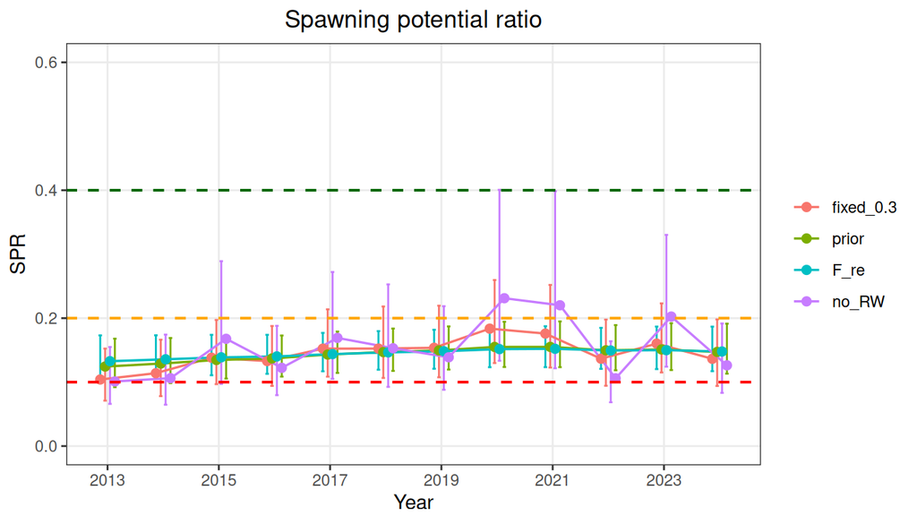

```r
plot_spr(fits_F, ci = TRUE)
```

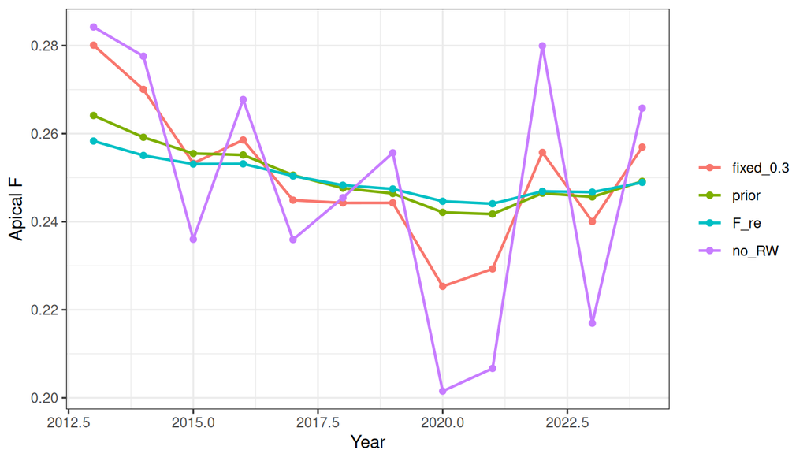

```r
F_by_option <- FLQuants(fixed_0.3 = fits_F$fixed_0.3$report$Fap,
                        prior     = fits_F$prior$report$Fap,
                        F_re      = fits_F$F_re$report$Fap,
                        no_RW     = fits_F$no_RW$report$Fap)
ggplot(F_by_option, aes(year, data, colour = qname)) +
  geom_line(linewidth = 0.8) + geom_point(size = 1.5) +
  labs(x = "Year", y = "Apical F", colour = NULL) + theme_bw()
```

The estimated $\sigma_F$ of the penalised and random-effects options is much smaller than 0.3, so their F trajectories are smoother; without a random walk F follows each year’s composition. To see what $\sigma_F$ does, the next runs fix it at a range of values (`sigmaF_values`):

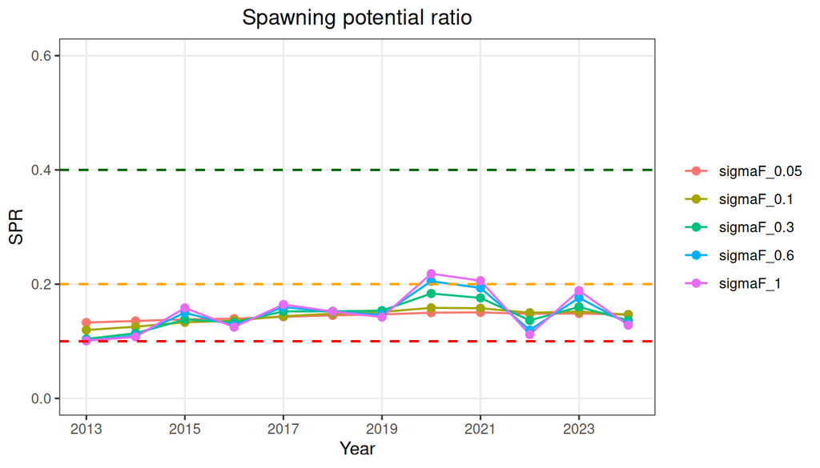

```r
sigmaF_values <- c(0.05, 0.1, 0.3, 0.6, 1)

fits_sigmaF <- Map(function(sF) {
  fiticc(lfd200, stklen, sel_fun = sel_fun, catch_by_gear = cbg,
         settings = list(CVL = 0.1, obs_model = "dm", sigmaF = sF), se = FALSE)
}, sigmaF_values)
names(fits_sigmaF) <- paste0("sigmaF_", sigmaF_values)

plot_spr(fits_sigmaF)
```

```r
data.frame(sigmaF   = sigmaF_values,
           SPR_last = round(sapply(fits_sigmaF, sprcur_flicc), 3),
           neg_logL = round(sapply(fits_sigmaF, function(fit) fit$opt$objective), 1))
```

```
#>             sigmaF SPR_last neg_logL
#> sigmaF_0.05   0.05    0.147  14344.7
#> sigmaF_0.1    0.10    0.147  14359.0
#> sigmaF_0.3    0.30    0.136  14380.8
#> sigmaF_0.6    0.60    0.131  14394.2
#> sigmaF_1      1.00    0.128  14404.4
```

Small values force F (and SPR) towards a flat line; from about 0.3 upward the trajectories change little. The objective (`neg_logL`) includes the random-walk penalty, which is why it cannot be used to choose $\sigma_F$ directly: it always favours the smallest value that the compositions tolerate.

## 11.1 Default: sigmaF fixed

`sigmaF = 0.3` (the default) fixes the year-to-year standard deviation of log F, roughly a 30% typical annual change. It is fast, cannot collapse, and the simulations showed that it removes most of the smoothing lag (next section). Change it where fleet dynamics are known to be smoother (0.2) or more variable (0.5).

## 11.2 Estimating sigmaF with a prior (penalised)

With `prior_sigmaF = c(mu, sd, 1)`, $\sigma_F$ is a fixed-effect parameter and the objective is
$$-\log L = -\log L_{data} - \sum_{g,y} \log \phi\left(\log F_{g,y} - \log F_{g,y-1};\, 0, \sigma_F\right)
- \log \phi\left(\log \sigma_F;\, \mu, sd\right).$$
Each random-walk term contributes $-\log \sigma_F$, so the joint maximum favours small $\sigma_F$ with flat F whenever the data do not resist: the estimate is pulled down (here 0.079), and only the prior keeps it away from 0. Without a prior (`prior_sigmaF = c(NA, NA, 1)`) it collapses; FLicc warns.

## 11.3 F as random effects (`F_re = TRUE`)

The log F are integrated out,
$$L(\theta) = \int L_{data}(\theta, \mathbf F)\, p(\mathbf F \mid \sigma_F)\, d\mathbf F,$$
by the Laplace approximation (TMB): for each value of the other parameters $\theta$ (selectivity, $\sigma_F$), the F path is optimised and the curvature around it enters the marginal likelihood. Consequences:

- $\sigma_F$ is estimated from the marginal likelihood, which properly accounts for the uncertainty of the F path (here 0.053). It can still go to small values when the compositions carry little year-to-year information; a weak prior `c(log(0.3), 0.5, 1)` is used unless another is given.
- Standard errors (e.g. of log SPR) include the uncertainty of the F process.
- Fitting is slower:

```r
system.time(fiticc(lfd200, stklen, sel_fun = sel_fun, catch_by_gear = cbg, settings = f_settings$fixed_0.3))
```

```
#>    user  system elapsed
#>   0.667   0.000   0.667
```

```r
system.time(fiticc(lfd200, stklen, sel_fun = sel_fun, catch_by_gear = cbg, settings = f_settings$F_re))
```

```
#>    user  system elapsed
#>   5.953   0.008   5.962
```

Use it for a final assessment and to estimate $\sigma_F$ once; then fix it for repeated fits: `sigmaF = sigmaF_flicc(fit_re)`. `F_re = TRUE` with `sigmaF` given keeps the random effects but fixes $\sigma_F$.

## 11.4 No random walk and separate years

`prior_sigmaF = FALSE` estimates each year’s F freely with shared selectivity (LBSPR fitted year by year, with common selectivity): no smoothing lag, but noisier F and no information for years without data. `by_year = TRUE` fits each year completely separately (including selectivity).

| Option | Settings | sigmaF | Use |
| --- | --- | --- | --- |
| fixed (default) | `sigmaF = 0.3` | fixed | routine, MSE, ensembles |
| penalised with prior | `prior_sigmaF = c(log(0.5), 0.3, 1)` | estimated, pulled down | comparison with earlier versions |
| random effects | `F_re = TRUE` | marginal likelihood | final assessment; estimate sigmaF once |
| no random walk | `prior_sigmaF = FALSE` | – | complete data, maximum responsiveness |
| separate years | `by_year = TRUE` | – | checks of selectivity change |

## 11.5 Joint fit versus each year separately

`by_year = TRUE` fits every year on its own and re-estimates all parameters, including selectivity, for each year: the LBSPR-style approach. The comparison below uses the same data and settings as the reference fit `fit`.

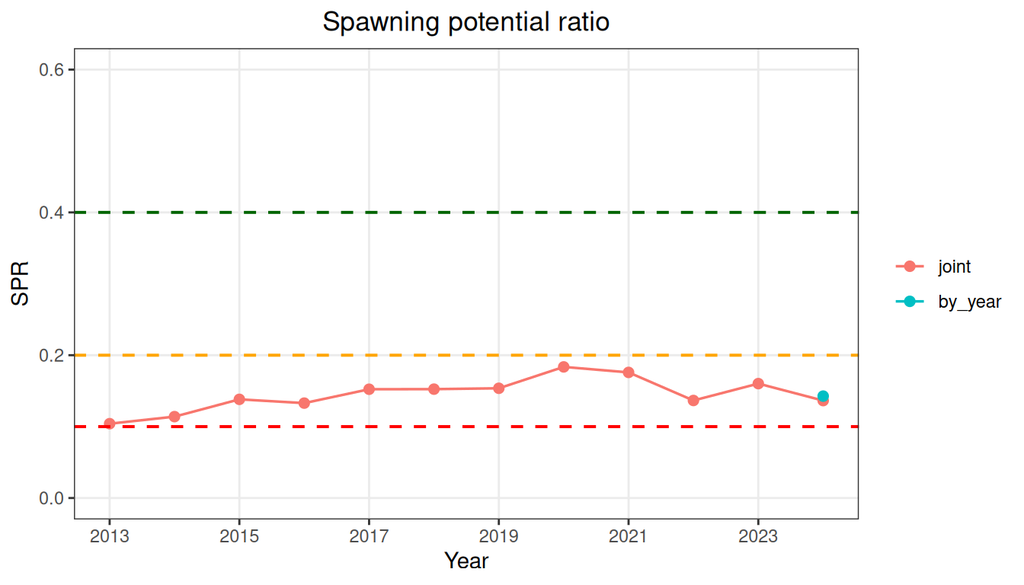

```r
fit_by_year <- fiticc(lfd200, stklen, sel_fun = sel_fun, catch_by_gear = cbg,
                      settings = list(CVL = 0.1, obs_model = "dm"), by_year = TRUE)

plot_spr(list(joint = fit, by_year = fit_by_year))
```

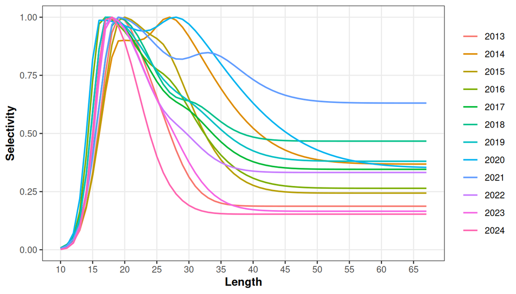

```r
plot_sel(flicc_stklen(fit_by_year))
```

## 11.6 Lag under changing F

An equilibrium model explains each year’s composition by the equilibrium at that year’s F. After a change in F, the large fish adjust only over many years, so the estimated SPR lags behind (*simulation*, rebuild from 3x to 0.7x Fmsy):

| F model | SPR trend recovered, no cut | with cut at 0.8 Linf |
| --- | --- | --- |
| sigmaF estimated (collapsing) | 14% | 26% |
| sigmaF fixed 0.3 | 27% | 50% |
| sigmaF fixed 1 | 29% | 57% |
| no random walk | 30% | 59% |

The smoothing lag of the random walk is largely removed at sigmaF = 0.3; larger values add little responsiveness but more year-to-year noise (+10 to +50%). The rest of the lag comes from the data (the tail carries the memory of past F) and from recruitment rising during recovery under a stock-recruitment relationship. In a rebuild from deep depletion the equilibrium model stays pessimistic.

# 12 Growth variability and life-history priors

## 12.1 CVL

`CVL` is the coefficient of variation of Linf among growth-type groups. It sets how far individual growth spreads the length composition, mostly in the tail: the fastest-growing groups determine how many fish occur near and beyond Linf. It is fixed at its input value unless `CVL.sd` is given; typical values are 0.07-0.15.

The sensitivity below refits the model for three CVL values (`cvl_values`), without and with a tail cut at 47 cm; `Map()` runs one fit per value.

```r
cvl_values <- c(0.07, 0.10, 0.13)

fits_cvl <- Map(function(cvl) {
  fiticc(lfd200, stklen, sel_fun = sel_fun, catch_by_gear = cbg,
         settings = list(CVL = cvl, obs_model = "dm"), se = FALSE)
}, cvl_values)
names(fits_cvl) <- paste0("CVL_", cvl_values)

fits_cvl_cut <- Map(function(cvl) {
  fiticc(lfd200, stklen, sel_fun = sel_fun, catch_by_gear = cbg,
         settings = list(CVL = cvl, obs_model = "dm", tail_cut = 47), se = FALSE)
}, cvl_values)
names(fits_cvl_cut) <- paste0("CVL_", cvl_values, "_cut47")

cvl_table <- data.frame(CVL       = cvl_values,
                        SPR_no_cut = round(sapply(fits_cvl, sprcur_flicc), 3),
                        SPR_cut47  = round(sapply(fits_cvl_cut, sprcur_flicc), 3),
                        row.names = NULL)
cvl_table
```

```
#>    CVL SPR_no_cut SPR_cut47
#> 1 0.07      0.159     0.131
#> 2 0.10      0.136     0.124
#> 3 0.13      0.116     0.116
```

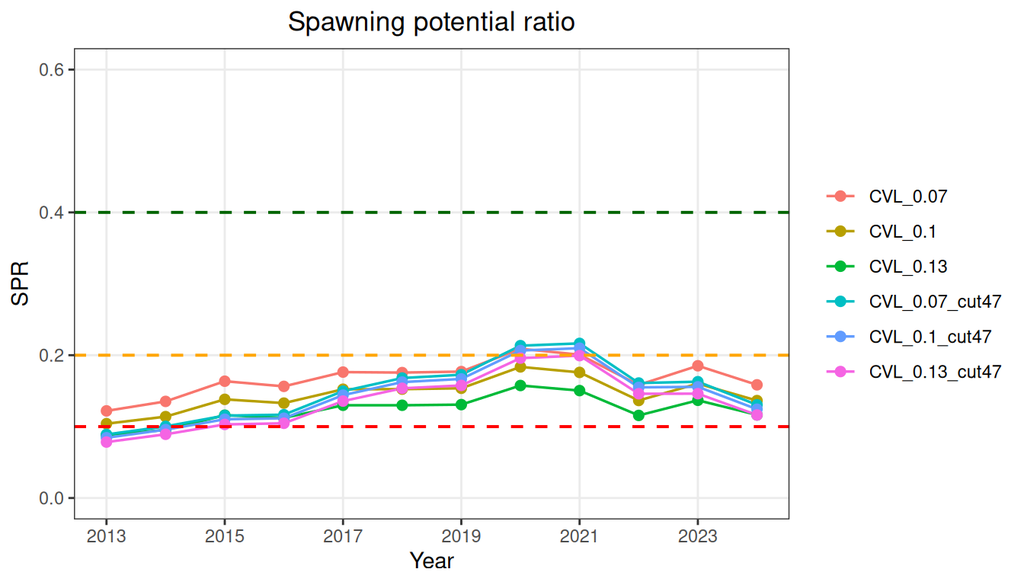

```r
plot_spr(c(fits_cvl, fits_cvl_cut))
```

Status is sensitive to CVL because CVL shapes the tail: here SPR ranges 0.116-0.159 over CVL 0.07-0.13 without a cut and 0.116-0.131 with a cut at 47 cm.

## 12.2 maxsd and ngtg

The growth groups are placed at $z_h$ on `seq(-maxsd, maxsd, length = ngtg)` with normal weights. Truncating the normal at `maxsd` reduces the realised CV of the groups below CVL and caps the largest group at $L_\infty(1 + \text{maxsd}\cdot\text{CVL})$:

The realised spread can be computed directly from the group positions `z` and their normal weights `w`; the factor multiplies CVL:

```r
z <- seq(-2, 2, length.out = 13)          # maxsd = 2, ngtg = 13 (default)
w <- dnorm(z) / sum(dnorm(z))
sqrt(sum(w * z^2))                        # realised CV factor
```

```
#> [1] 0.9115967
```

```r
z <- seq(-3, 3, length.out = 19)          # maxsd = 3, ngtg = 19
w <- dnorm(z) / sum(dnorm(z))
sqrt(sum(w * z^2))
```

```
#> [1] 0.9918311
```

```r
55.7 * (1 + c(2, 3) * 0.1)                # largest group Linf for maxsd 2 and 3
```

```
#> [1] 66.84 72.41
```

With the LBSPR default (`maxsd = 2`, 13 groups) the realised CV is about 0.9 x CVL; `maxsd = 3` gives almost exactly CVL and allows larger fish. The number of groups matters little beyond about 13.

The fits below compare the two settings (`maxsd_values` with matching `ngtg_values`), without and with the tail cut; `Map()` takes the two vectors in parallel.

```r
maxsd_values <- c(2, 3)
ngtg_values  <- c(13, 19)

fits_maxsd <- Map(function(maxsd, ngtg) {
  fiticc(lfd200, stklen, sel_fun = sel_fun, catch_by_gear = cbg,
         settings = list(CVL = 0.1, obs_model = "dm", maxsd = maxsd, ngtg = ngtg), se = FALSE)
}, maxsd_values, ngtg_values)

fits_maxsd_cut <- Map(function(maxsd, ngtg) {
  fiticc(lfd200, stklen, sel_fun = sel_fun, catch_by_gear = cbg,
         settings = list(CVL = 0.1, obs_model = "dm", maxsd = maxsd, ngtg = ngtg,
                         tail_cut = 47), se = FALSE)
}, maxsd_values, ngtg_values)

data.frame(maxsd      = maxsd_values,
           ngtg       = ngtg_values,
           SPR_no_cut = round(sapply(fits_maxsd, sprcur_flicc), 3),
           SPR_cut47  = round(sapply(fits_maxsd_cut, sprcur_flicc), 3))
```

```
#>   maxsd ngtg SPR_no_cut SPR_cut47
#> 1     2   13      0.136     0.124
#> 2     3   19      0.131     0.122
```

Recommendation: keep the LBSPR default for comparability and treat `maxsd = 3` as a sensitivity; with a tail cut the choice matters little, because the affected bins lie far above the cut. The effective CV matters when CVL is taken from external growth studies: with `maxsd = 2`, a CVL input of 0.1 corresponds to a realised spread of about 0.09.

## 12.3 Estimating Linf, M/k and CVL with priors

By default growth and natural mortality are fixed. `linf.sd`, `Mk.sd` and `CVL.sd` estimate them with normal priors on the log scale around the inputs:
$$\log L_\infty \sim N(\log L_\infty^{in}, \texttt{linf.sd}^2), \quad
\log (M/k) \sim N(\log (M/k)^{in}, \texttt{Mk.sd}^2), \quad
\log \mathrm{CVL} \sim N(\log \mathrm{CVL}^{in}, \texttt{CVL.sd}^2),$$
so each sd is approximately a CV (e.g. `linf.sd = 0.05`: about ±10% at 95%).

The fit below estimates all three with priors. The estimates are on the log scale: $L_\infty$ = `exp(log_Linf)`, $M/k$ = `exp(log_Mk)` and CVL = `1 / sqrt(exp(log_Galpha))`; the column `se` is approximately the posterior CV (for `log_Galpha` divide by 2).

```r
fit_pri <- fiticc(lfd200, stklen, sel_fun = sel_fun, catch_by_gear = cbg,
                  settings = list(CVL = 0.1, obs_model = "dm",
                                  linf.sd = 0.05, Mk.sd = 0.1, CVL.sd = 0.25))

est <- fit_pri$par[fit_pri$par$par %in% c("log_Linf", "log_Mk", "log_Galpha"), ]
est
```

```
#>          par       mpd        se
#> 1   log_Linf 4.0350242 0.0344286
#> 2 log_Galpha 4.7665282 0.3992806
#> 3     log_Mk 0.6431736 0.0935413
```

```r
exp(est$mpd[est$par == "log_Linf"])            # Linf (input 55.7)
```

```
#> [1] 56.54429
```

```r
exp(est$mpd[est$par == "log_Mk"])              # M/k  (input 0.162 / 0.08 = 2.03)
```

```
#> [1] 1.902509
```

```r
1 / sqrt(exp(est$mpd[est$par == "log_Galpha"])) # CVL  (input 0.1)
```

```
#> [1] 0.09224898
```

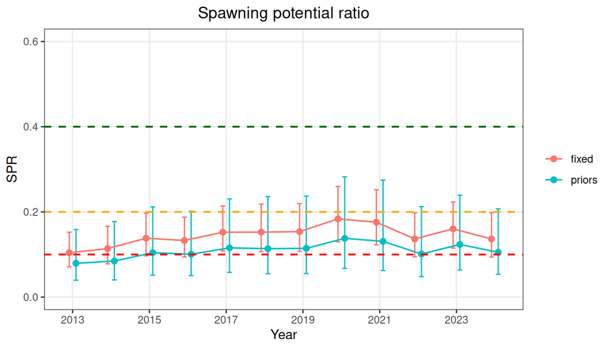

```r
plot_spr(list(fixed = fit, priors = fit_pri), ci = TRUE)
```

Here the length data pull Linf up to about 56.5 (posterior CV 0.034 against a prior CV of 0.05), and because a larger Linf means the fish in the catch are relatively younger, SPR drops markedly. The posterior CVs of M/k and CVL stay close to their prior CVs: the data say little about them. A shift of this size in Linf is a finding to check against growth studies, not a result to accept; run the assessment with Linf fixed at the alternative values as a sensitivity.

Notes:

- **k** is not estimated separately: the length model depends on M/k (and Z/k), so uncertainty in k and M is expressed through `Mk.sd`. k still sets the time scale of the annual F estimates (F is estimated as F/k).
- Length data carry limited information on Linf and CVL, and both are confounded with dome-shaped selectivity and the tail; a posterior CV close to the prior CV means the data are uninformative. Large moves away from the input (several prior SDs) indicate a conflict between the data and the life history, to be investigated rather than accepted.
- For ensembles, drawing the life-history parameters and keeping them fixed in each fit (`mc_flicc()`) is usually better behaved than estimating them.

# 13 Tail of the length composition

## 13.1 Tail cut

`tail_cut = L` excludes bins with lower bound $\geq L$ from the likelihood; observed and predicted compositions are truncated and the predictions renormalised,
$$\pi_{l \mid L < L_{cut}} = \pi_l \Big/ \sum_{l' : L_{l'} < L_{cut}} \pi_{l'} .$$
This is exact conditioning: the model still describes the whole population with its input CVL, SPR and reference points use all lengths, and CVL needs no adjustment. `tail_cut` is an **absolute length** (as `Lplus`), so all sensitivity runs and ensemble draws use the same bins. (Values <= 1.5 are read as a fraction of Linf, with a warning.)

```r
fit_cut <- fiticc(lfd200, stklen, sel_fun = sel_fun, catch_by_gear = cbg,
                  settings = list(CVL = 0.1, obs_model = "dm", tail_cut = 47))  # ~0.85 x Linf
fit_cut$tmb_data$LLB[fit_cut$tmb_data$cut_bin + 1]
```

```
#> [1] 47
```

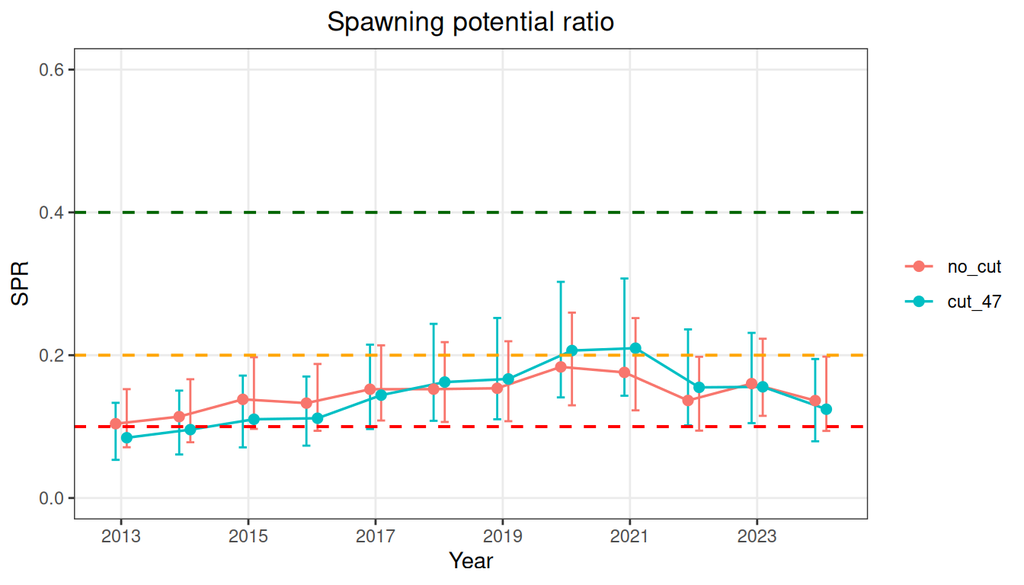

```r
plot_spr(list(no_cut = fit, cut_47 = fit_cut), ci = TRUE)
```

*Simulation* (stable F, correct Linf unless stated):

|  | no cut | cut at 0.80-0.85 x Linf |
| --- | --- | --- |
| CVL input 0.07 / 0.10 / 0.13 (true 0.1) | +9 / -1 / -11% | +13 / +9 / +4% |
| strong dome on one gear fitted as logistic | -17% | +1% |
| SPR trend recovered in a rebuild (sigmaF 0.3) | 27% | ~50% |
| Linf input 0.9 / 1.1 x true | +91 / -40% | +74 / -28% |

The cut halves the CVL sensitivity, removes the bias of a strong unmodelled dome and roughly doubles responsiveness; it costs a small positive bias (+7 to +10%) and more noise under stable F, and does not remove the Linf sensitivity. Starting value: 0.80-0.85 x Linf, fixed across fits.

## 13.2 Plus group, robust likelihood, GTG range

- `Lplus = L` pools bins with lower bound $\geq L$ into one (the total counts, the shape does not).
- `rob_eps = 0.001` bounds the cost of a few fish in bins the model barely reaches.
- The largest growth group stops at $L_\infty(1 + \text{maxsd}\cdot\text{CVL})$; with `maxsd = 2` the effective CV is about 0.9 x CVL. Fish beyond it get near-zero probability; a tail cut makes this irrelevant.

# 14 Reference points and status

## 14.1 Fspr

The fit stores Fspr for `settings$spr_ref` (default 40%), computed in TMB:

```r
fspr_flicc(fit)                 # stored Fspr40
```

```
#> [1] 0.1114372
```

```r
fspr_flicc(fit, spr = 30)       # computed
```

```
#> [1] 0.1487164
```

```r
fcur_flicc(fit); sprcur_flicc(fit)
```

```
#> [1] 0.256953
#> [1] 0.1364312
```